# Introduction to statistics for hypothesis testing

This Jupyter notebook is intended to help explain statistical methods for hypothesis testing using code and examples (with minimal mathematics). It is restricted to univariate tests on continuous data, and focuses on issues that arise in neuroimaging, e.g, when there are multiple tests on topographically organised and smooth data. The code is written to aid comprehension, rather than for speed/efficiency. Some sections require having run code in preceding sections. It assumes basic knowledge of programming (eg. loops / functions / vectorisation). It was originally written for the MRC CBU's COGNESTIC Summer School, but can stand-alone. It starts with sampling theory, central limit thoerem and randomisation testing, then proceeds to null hypothesis testing (error rate and power), focusing on T-tests and including Bayes Factors, then moves to the multiple comparison problem, height and cluster-level family-wise and false-disovery correction, before introducing the General Linear Model, ANOVAs, F-tests, error nonsphericity, error partitioning, multiple regression, timeseries, and finishes with Linear Mixed Effects models.

Needs python 3.11+, numpy, matplotlib, scipy, polars, pymer (and notebook and ipykernel of course)

Any corrections/comments welcomed. Rik Henson, May 2024. rik.henson@mrc-cbu.cam.ac.uk. Thanks to Danny Mitchell for comments.

## Random Sampling

Let's assume we have data from a large population of people, where the values have a Gaussian distribution with mean of 0 and standard deviation (std) of 1 (a "unit normal" distribution). We will create this distribution explicitly below for the sake of comprehension (even though most programming languages allow you to draw randomly from such a distribution on the fly):

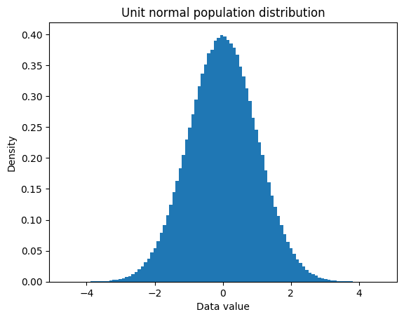

```python
import numpy as np
import matplotlib.pyplot as plt

np.random.seed(1) # Initialise random seed
pop_size = int(1e6) # Needs to be big (but not exceed RAM!)
pop_mean = 0
pop_std = 1
pop = np.random.randn(pop_size,1)*pop_std + pop_mean # Draw randomly from distribution
# Since pop_size finite, re-centre (important if pop_size not big enough)
pop = (pop - np.mean(pop))/np.std(pop) # Reset to exactly unit normal ("Z-scoring")
pop = pop*pop_std + pop_mean # Re-set to desired std and mean
pdf, bin_edges = np.histogram(pop, bins=100, density=True) # Plot histogram
plt.figure(); plt.bar((bin_edges[:-1] + bin_edges[1:]) / 2, pdf, width=bin_edges[1] - bin_edges[0])
plt.title('Unit normal population distribution'); plt.xlabel('Data value'); plt.ylabel('Density'); plt.show()
```

Let's pretend we don't know the mean of the population, but want to estimtate it by drawing a random sample from the population.

```python
samp_size = int(1e2) # Sample size
select = np.random.randint(0, len(pop)-1, size=(samp_size, 1)) # random subset of people from population
samp = pop[select.squeeze()] # their values
print(f'Mean of one sample = {np.mean(samp):.3f}')
```

```
Mean of one sample = -0.003
```

We can make this process a function (technically, this is sampling with replacement, but when samp_size << pop_size, repeat values are extremely unlikely, and this is faster than sampling without replacement):

```python
def sample_pop(pop, samp_size, num_samp):
    indices = np.random.randint(0, len(pop), size=(samp_size, num_samp))
    return np.squeeze(pop[indices], axis = -1)
```

But of course there will be uncertainty associated with any such estimate of the population mean from a smaller sample. We can see this by repeating the process many times, to get a new distribution, but this time of sample *means*:

```
Std of distribution of means of samples = 0.100
```

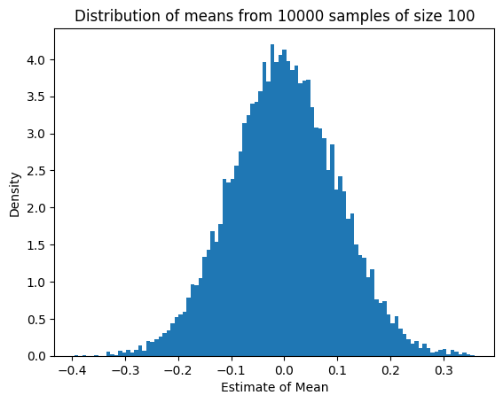

```python
num_samp = int(1e4) # Number of samples
samp = sample_pop(pop, samp_size, num_samp)
mean_vals = np.mean(samp, axis=0)
pdf, bin_edges = np.histogram(mean_vals, bins=100, density=True)
plt.figure(); plt.bar((bin_edges[:-1] + bin_edges[1:]) / 2, pdf, width=bin_edges[1] - bin_edges[0])
plt.title(f'Distribution of means from {num_samp:d} samples of size {samp_size:d}')
plt.xlabel('Estimate of Mean'); plt.ylabel('Density')
print(f'Std of distribution of means of samples = {np.std(mean_vals):.3f}')
```

Note that the std of the distribution of mean estimates ("standard error of mean") is equal to the std of the population divided by the square-root of the sample size - something we will come back to later.

### Central Limit Theorem

Another thing worth noting about this distribution of mean estimates is that, with big enough sample size, it will approach a Gaussian distribution, even if the original population distribution is not Gaussian ("Central Limit Theorem"). So the population might be highly skewed or kurtotic:

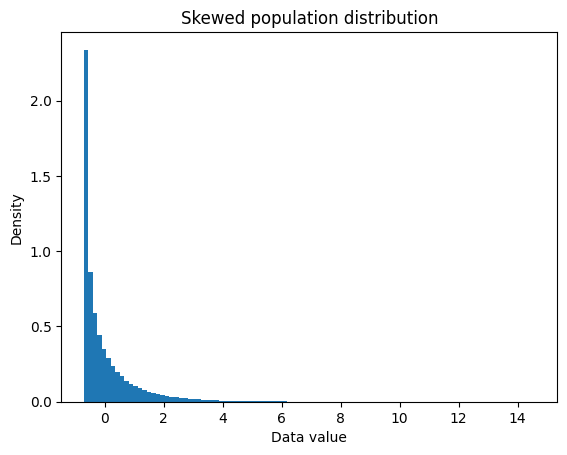

```python
pop2 = pop**2 # Create a positively skewed distribution
pop2 = (pop2 - np.mean(pop2, axis=0)) / np.std(pop2) # Reset to have mean of 0 and std of 1 (if were Gaussian!)

pop3 = pop**3 # Create a positively kurtotic distribution
pop3 = (pop3 - np.mean(pop3, axis=0)) / np.std(pop3) # Reset to have mean of 0 and std of 1 (if were Gaussian!)

pdf, bin_edges = np.histogram(pop2, bins=100, density=True)
plt.figure(); plt.bar((bin_edges[:-1] + bin_edges[1:]) / 2, pdf, width=bin_edges[1] - bin_edges[0])
plt.title('Skewed population distribution'); plt.xlabel('Data value'); plt.ylabel('Density');

#pdf, bin_edges = np.histogram(pop3, bins=100, density=True)
#plt.figure(); plt.bar((bin_edges[:-1] + bin_edges[1:]) / 2, pdf, width=bin_edges[1] - bin_edges[0])
#plt.title('Kurtotic population distribution'); plt.xlabel('Data value'); plt.ylabel('Density');
```

But look what happens to distribution of means as sample size increases:

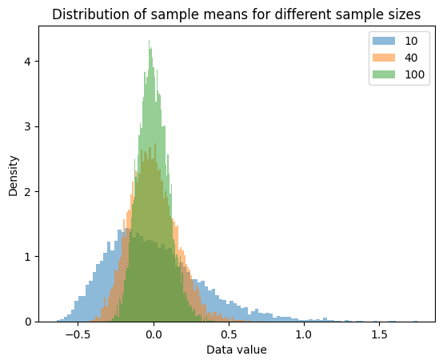

```python
samp_size = [10, 40, 100] # Explore range of sample sizes
plt.figure()
for s, size in enumerate(samp_size):
    samp = sample_pop(pop2, samp_size[s], num_samp)
    mean_vals = np.mean(samp, axis=0)
    pdf, bin_edges = np.histogram(mean_vals, bins=100, density=True)
    plt.bar((bin_edges[:-1] + bin_edges[1:]) / 2, pdf, width=bin_edges[1] - bin_edges[0], alpha = 0.5)
plt.title('Distribution of sample means for different sample sizes')
plt.legend([f'{size}' for size in samp_size]); plt.xlabel('Data value'); plt.ylabel('Density');
```

Not only does the spread of the distributions decrease as sample size increases, but the distributions become more Gaussian (e.g, the distribution from a sample size of 10 is still skewed, like the native population, but hardly skewed when sample size is 100).

## Randomisation (permutation) testing

Normally we only have one sample, and hence only one mean, so how do we know whether the population mean is, for example, greater than 0? One way to estimate the variability of our mean estimate is to re-sample randomly, but this time from our single sample (rather than the population). One approach is to select values randomly with replacement, which is called "boot-strapping". Boot-strapping is sometimes used to estimate confidence intervals, but it is not ideal for the hypothesis testing we will do below. Another way that is more appropriate for hypothesis testing is called "permutation testing" (sampling without replacement). If, for example, we assume only that the parent distribution is symmetrical around 0, then we could create an equivalent new sample by randomly flipping the sign (with 50% probability) of each value of our real sample. (This is equivalent to randomly switching condition labels for each participant in a two-tailed, paired T-test, as covered later). This is a type of "randomisation" test (also called a "non-parametric" test). If we repeat this a large number of times, we get an estimate of the distribution of the mean:

```
Std of distribution of means from randomisation = 0.086
```

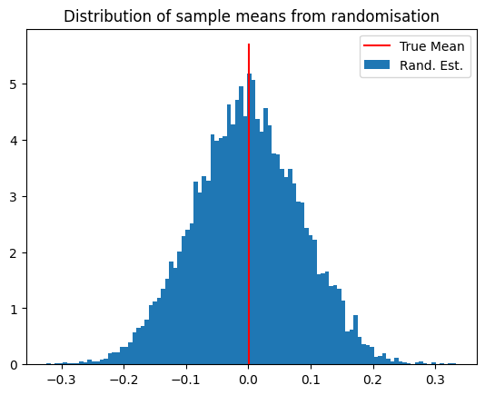

```python
np.random.seed(1) # Initialise random seed
samp_size = int(1e2)
one_sample = sample_pop(pop, samp_size, 1)
num_rand = int(1e4) # Number of randomisations
mean_vals = np.empty(num_rand)
for r in range(num_rand):
    #resamp = one_sample[np.ceil(np.random.rand(samp_size, 1)*(samp_size-1)).astype(int)] # bootstrap sample with replacement (np.random.rand(x.shape[0], num_rand) * (x.shape[0] - 1)).astype(int)
    resamp = np.multiply(one_sample.T, np.sign(np.random.rand(samp_size) - 0.5)) # permutation sample with replacement
    mean_vals[r] = np.mean(resamp)
tmp = np.sign(np.random.rand(samp_size) - 0.5)
pdf, bin_edges = np.histogram(mean_vals, bins=100, density=True)
plt.figure(); plt.bar((bin_edges[:-1] + bin_edges[1:]) / 2, pdf, width=bin_edges[1] - bin_edges[0])
true_mean = np.mean(one_sample)
plt.plot([true_mean, true_mean], [0, 1.1*np.max(pdf)], 'r-')
plt.title('Distribution of sample means from randomisation'); plt.legend(['True Mean', 'Rand. Est.']);
print(f'Std of distribution of means from randomisation = {np.std(mean_vals):.3f}')
```

Notice that the standard error of the mean is again close to expected value of pop_std/sqrt(samp_size). This randomised distribution can be used to calculate confidence intervals around the mean, e.g, the upper part of the 95% confidence interval can be obtained by sorting the estimates of the mean from smallest to largest, and selecting the value just above the 95th percentile (assuming num_rand>100; see later):

```python
mean_vals = sorted(mean_vals)
ci95 = mean_vals[int(np.floor(0.95 * len(mean_vals)))]
print(f'Sample mean is {true_mean:.3f} with upper 95-percent confidence interval of {ci95:.3f}')
```

```
Sample mean is 0.001 with upper 95-percent confidence interval of 0.141
```

In most cases (but does depend on your random seed!), the true mean should be less than the 95% upper confidence value.

## Hypothesis Testing

We can now have a first stab at hypothesis testing. In traditional "null hypothesis signficance testing" (NHST), to test our hypothesis that the mean of the population is greater than 0 (sometimes called the alternate hypothesis, H1), we strive to reject the null hypothesis (H0) that the mean of the population is zero. To test this with our sample, we can use the randomise_one_sample function below, which just uses the permutation code above (or other randomisation method) and returns the proportion of permuted means that are as big, or bigger, than the actual sample mean:

```python
def randomise_one_sample(y, num_rand=int(1e4), two_tailed=False, rand_method='permute', property='mean', critical_value=0):
    # Estimate probability that some property of a sample is greater (or smaller, if two-tailed)
    # than a critical value using a certain randomisation method.

    if property == 'mean':
        property_lambda = lambda y: np.mean(y, axis=0)
    elif property == 'tstat':
        property_lambda = lambda y: np.mean(y, axis=0) / (np.std(y, axis=0, ddof=1) / np.sqrt(y.shape[0]))
    else:
        raise ValueError(f'Randomised property {property} unknown')

    num_samp = y.shape[1]

    if rand_method == 'permute':
        select = lambda x, num_rand: np.repeat(x, num_rand, axis=1) * np.sign(np.random.rand(x.shape[0], num_rand) - 0.5)
    elif rand_method == 'bootstrap':
        select = lambda x, num_rand: x[np.ceil(np.random.rand(x.shape[0], num_rand) * (x.shape[0] - 1)).astype(int)]
#        for s in range(num_samp):
#            y[:,s] = y[:,s] - property_lambda(y[:,s])  # Set property to 0 for null
    else:
        raise ValueError(f'Randomisation method {rand_method} unknown')

    y = y - critical_value  # Re-centre to critical value

    prop = np.full((num_samp), np.nan)
    for s in range(num_samp):
        ys = y[:, s]
        actual_value = property_lambda(ys)
        yr = select(ys[:,np.newaxis], num_rand)
        rand_dist = property_lambda(yr).T

        # Proportion of randomisations greater than actual value (equality and adding 1 to include actual sample itself)
        if two_tailed:
            prop[s] = (np.sum(np.abs(rand_dist) >= np.abs(actual_value)) + 1) / (num_rand + 1)
        else:
            prop[s] = (np.sum(rand_dist >= actual_value) + 1) / (num_rand + 1)

    if num_samp == 1:
        prop = prop[0]

    return prop
```

So for example:

```python
p_value = randomise_one_sample(one_sample, num_rand, two_tailed=False, rand_method='permute', property='mean')
print(f'Proportion of randomised means greater than sample mean = {p_value:.3f}')
```

```
Proportion of randomised means greater than sample mean = 0.494
```

Under H0, this proportion is equally likely to lie anywhere between 0 and 1. This proportion is an estimate of the "p-value": the probablity of getting a statistic as large or larger than a critical value, given that H0 is true. We generally want this p-value to be small, i.e. want minimal risk of falsely rejecting H0 when it is in fact true. This threshold is called "alpha" and is conventionally set at .05, ie 1 in 20 chance that we conclude the population mean is not zero when it is in fact. This is also called the false positive rate (or "type I error" rate).

*Interesting factoid: What is the origin of 0.05 for alpha? A story says that the statistician Sir Ronald Fisher was crossing a court of his Cambridge college when someone yelled: "What odds would you trust for something not happening by chance?". Apparently he replied "1 in 20", perhaps without intending that this should become scientific dogma (though 0.05 was also used in his publications).*

### False positive rate and power

To check that our test does control false positive rate (FPR), we can simulate drawing many samples from the population (eg. doing many experiments), and calculate the proportion of experiments that give a false positive. We're going to assume a small sample of 20 people though:

```python
np.random.seed(1) # Initialise random seed
alpha = 0.05
samp_size = 2*int(1e1) # a small sample size of 20
#samp_size = int(1e2) # larger sample size of 100
num_rand = int(1e4)  # to accurately estimate p-value
num_samp = int(1e4)  # to accurately estimate false positive rate (FPR)

pop_H0 = pop   # Gaussian
#pop_H0 = pop2 # Non-Gaussian (skewed) (not symmetrical ;-)
#pop_H0 = pop3 # Non-Gaussian (kurtotic) (but still symmetrical ;-)
p_values = np.full((num_samp,), np.nan)
for s in range(num_samp):
    samp = sample_pop(pop_H0, samp_size, 1)  # Take sample from Skewed population
    p_values[s] = randomise_one_sample(samp, num_rand, two_tailed=False, rand_method='permute', property='mean')
#    p_values[s] = randomise_one_sample(samp, num_rand, two_tailed=False, rand_method='bootstrap', property='mean')
#    p_values[s] = randomise_one_sample(samp, num_rand, two_tailed=False, rand_method='permute', property='tstat')
fpr = np.sum(p_values < alpha) / num_samp
print(f'Randomised (false) positive rate when population has zero-mean = {fpr:.3f}')
```

```
Randomised (false) positive rate when population has zero-mean = 0.048
```

This shows that our permutation test does ensure that only around 5% of experiments would produce a false positive.

**Exercise: What happens to the FPR for a skewed or kurtotic distribution? Can you explain why FPR is controlled at alpha for one but not other (think about assumption made by our sign-switching randomisation method). Or what happens when you bootstrap instead?**

Note that the resolution of the estimated p-value depends on the number of random resamples. For example, if num_rand=1e2, then we could only estimate the p-value to 2 decimal places. In general, a minimum num_rand of 1e4 is recommended. However, p-value resolution can also be affected by the sample size if the samp_size is small. For example, if samp_size=10, there are 2^samp_size=1024 possible permutations for a one-sample test. Furthermore, the randomise_one_sample function does not enumerate all such permutations - it randomly samples possible permutations - making it likely that the same permutation will be sampled more than once if the sample size is not large enough (proper statistical software does enumerate all (or a subset of num_rand) permutations if feasible, but not done here to save time). So be wary of randomised p-values if the sample size is less than log2(1e4) ~ 14 (though note that greater resolution can be achieved by parametric approximation to the randomised distribution, e.g, using "percentile" interpolation).

But what if our hypothesis is true, and the population mean is greater than 0? How often does our test detect this? This is called the true positive rate (TPR), or "power" of a test (sometimes denoted as 1-beta, given a certain alpha). Let's create a new population with mean of 0.5 (which corresponds to a Cohen's d effect size of 0.5, since Cohen's d is mean divided by std, and here std=1):

```python
np.random.seed(1) # Initialise random seed
effect_size = 0.5            # Effect size for H1
pop_H1 = pop + effect_size   # (Gaussian population if H1 true)
#pop_H1 = pop3 + effect_size # (non-Gaussian population if H1 true)
p_values = np.full((num_samp,), np.nan)
for s in range(num_samp):
    samp = sample_pop(pop_H1, samp_size, 1)  # Take sample from population
    p_values[s] = randomise_one_sample(samp, num_rand, two_tailed=False, rand_method='permute', property='mean')
tpr = np.sum(p_values < alpha) / num_samp
print(f'Randomised (true) positive rate with population effect size {effect_size:.2f} = {tpr:.3f}')
```

```
Randomised (true) positive rate with population effect size 0.50 = 0.689
```

This is a power around 69% (normally we aim for >80%). Power increases with sample_size, as you will see later.

Note that there are other classes of non-parametric tests that have analytic solutions, e.g, those that ignore the magnitude of values and use only their ranks (or even just their signs). These rank-based statistics test the null hypothesis that the median (rather than mean) is zero, but are not considered here.

The real power of randomisation testing is that you can randomise any property (summary statistic) - you could randomise the median rather than mean for example. Indeed, later we are going to randomise properties like the maximum T-statistic, and the cluster size. In fact, it is preferable to randomise what are called pivotal statistics, which are statistics whose distribution does not depend on any unknown parameters. We know from above that the distribution of the sample mean depends on the unknown population standard deviation, so the mean is not a pivotal statistic. The Z-statistic and T-statistic are pivotal statistics, since they are normalised by the population standard deviation, so their values are independent of these. Nonetheless, permuting the mean is fine for present purposes.

## The T-test

Next though, we introduce the T-test. This test uses a T-statistic (sometimes called "Student's T") which is defined for one sample as the mean divided by the standard error of the mean:

```python
one_t = lambda y: np.mean(y, axis=0) / (np.std(y, axis=0, ddof=1) / np.sqrt(y.shape[0]))
```

Some maths can show that, under certain assumptions (that the distribution of the mean is Gaussian), the T-values under H0 follow a distribution called the T-distribution, which depends only on the degrees of freedom (df). For this simple case of a one-sample test, the df = samp_size - 1 (the -1 because we have used one df in our data to estimate the mean). From this, we can create a function that calculates the ("one-tailed"; see later) probability of obtaining a value of T or higher:

```python
from scipy.stats import t as tstat

T2p_higher = lambda T, df: 1 - tstat.cdf(T, df)
```

where "tstat.cdf" is the cumultive density function for the T distribution. This gives a p-value for a given T and df, eg:

```python
samp_size = int(1e2)
samp = sample_pop(pop_H1, samp_size, 1)  # Take sample from population
T = one_t(samp)       # use last sample from above
df = samp_size - 1    # degrees of freedom
p = T2p_higher(T, df) # p-value (use "p" because now parametric)
print(f'T({df}) = {T[0]:.2f}, p = {p[0]:.3f}')
```

```
T(99) = 6.20, p = 0.000
```

For this sample (drawn from population with mean of 0.5), we reject H0 (that population mean is 0) because p<.05.

This is called a "parametric" test, because it depends on a parametric (here Gaussian) assumption about the distribution of the property under test (here the mean). According to the CLT shown earlier, this assumption becomes more likely as the sample size increases (in fact, when df is very large, the T-distribution becomes Gaussian, and the p-value is equivalent to that for the Z-statistic, where Z = mean/std). For smaller samples, there are tests to determine whether the sample is likely to come from a normal distribution, but ironically, the smaller the sample size (and hence bigger the risk that the assumption of a Gaussian distribution of the mean is violated), the less sensitive such "tests of normality" become. This is why randomisation testing (even if done on the T-statistic itself), can be a more robust way of estimating the p-value when samples are small than using the parametric T-distribution.

*Interesting factoid: the "Student" in "Student's T-test" was the pseudonym of a statistician called Gosset, who worked for Guinness to quality control batches of beer, and used the pseudonym to avoid the ban of publishing research that might have commerical implications.*

We can also check that the T-test controls the FPR and gives similar Power (note how much quicker this is than randomisation testing!):

```python
np.random.seed(1) # Initialise random seed
samp_size = 2*int(1e1)
pop_H0 = pop
samp = sample_pop(pop_H0, samp_size, num_samp)
p = T2p_higher(one_t(samp), samp_size-1)
fpr = np.sum(p < alpha) / num_samp
print(f'False positive rate for T-test when H0 true = {fpr:.3f}')

pop_H1 = pop + effect_size
samp = sample_pop(pop_H1, samp_size, num_samp)
p = T2p_higher(one_t(samp), samp_size-1)
tpr = np.sum(p<alpha)/num_samp
print(f'True positive rate for T-test under H1 with effect size of {effect_size:.2f} = {tpr:.3f} (cf. for randomisation test above)')
```

```
False positive rate for T-test when H0 true = 0.051
True positive rate for T-test under H1 with effect size of 0.50 = 0.700 (cf. for randomisation test above)
```

However, what happens when parametric assumptions not met? We can repeat, but now drawing a large number of small samples from a non-Gaussian population (eg the kurtotic "pop3"):

```python
np.random.seed(1) # Initialise random seed
samp_size = 2*int(1e1)
#samp_size = int(1e4)
#pop_H0 = pop2
pop_H0 = pop3
samp = sample_pop(pop_H0, samp_size, num_samp)
p = T2p_higher(one_t(samp), samp_size-1)
fpr = np.sum(p < alpha) / num_samp
print(f'False positive rate for T-test when H0 true = {fpr:.3f}')

#pop_H1 = pop2 + effect_size
pop_H1 = pop3 + effect_size
samp = sample_pop(pop_H1, samp_size, num_samp)
p = T2p_higher(one_t(samp), samp_size-1)
tpr = np.sum(p<alpha)/num_samp
print(f'True positive rate for T-test under H1 with effect size of {effect_size:.2f} = {tpr:.3f}')
```

```
False positive rate for T-test when H0 true = 0.039
True positive rate for T-test under H1 with effect size of 0.50 = 0.797
```

The first thing to note is that the FPR is now less than alpha, i.e., the T-test has become conservative (ie. it "fails-to-safe"). In other words, the FPR has at least not increased above the accepted rate.

**Exercise: What happens to FPR for these non-Gaussian population distributions as sample size increases?**

So if the T-test is reasonably robust, you might wonder why we bother with permutation tests, given they are computationally expensive? One reason is that there are situations where parametric p-values from the T-statistic become capricious (see case of unequal variance for two-sample T-tests later). Another reason, as noted above, is that randomisation is more general, in that we can calculate probabilities for properties other than the mean or the T-statistic (such as the maximum; see later), which may not have a parametric (analytic) solution.

So far, we have been testing H1 that the mean is greater than 0. This is called a directional or "one-tailed" test. We can also perform a two-tailed test to ask whether the mean is simply different from 0, by using the absolute value of T:

```python
T2p_2tails = lambda T, df: 2*(1 - tstat.cdf(abs(T), df))
```

We can now calculate power curves for a two-tailed, one-sample T-test:

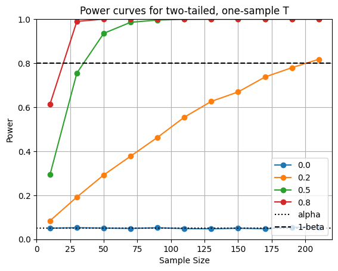

```python
samp_sizes = np.arange(10, 220, 20)
effect_sizes = [0, 0.2, 0.5, 0.8]
fig, ax = plt.subplots()
ax.set_title('Power curves for two-tailed, one-sample T');
ax.set_xlabel('Sample Size'); ax.set_ylabel('Power');
ax.set_xlim(min(samp_sizes)-10, max(samp_sizes)+10);
ax.set_ylim(0, 1); ax.grid(True);

pr = np.full((len(samp_sizes), len(effect_sizes)), np.nan)
for es, effect_size in enumerate(effect_sizes):
    pop_H1 = pop + effect_size
    for s, samp_size in enumerate(samp_sizes):
        samp = sample_pop(pop_H1, samp_size, num_samp)
        p = T2p_2tails(one_t(samp), samp_size-1)
        pr[s, es] = np.sum(p < alpha) / num_samp

for es, effect_size in enumerate(effect_sizes):
    ax.plot(samp_sizes, pr[:, es], 'o-', label=f'{effect_size:.1f}')
ax.axhline(y=alpha, linestyle=':', color='k', label='alpha')
ax.axhline(y=0.8, linestyle='--', color='k', label='1-beta')
ax.legend(loc='lower right');
```

So for what Cohen called a "medium" effect size of 0.5, you now need a sample size of ~30 for 80% power, but for what he called a "small" effect of 0.2, you need around 200.

## Bayes Factors

The above classical or "frequentist" statistics estimate the likelihood of getting a statistic as large or larger than that obtained from the data, given that the null hypothesis (that the effect is exactly zero) is true. One consequence of this is that, if this p-value does not fall below our alpha, then we cannot reject H0, but nor can we accept it ("absence of evidence is not evidence of absence"). A Bayes Factor (BF) on the other hand is the ratio of two likelihoods: the probability of exceeding that statistic value if H1 is true, relative to the same probability if H0 is true (this ratio is often called BF10; while its reciprocal is BF01). A high BF10 (e.g, 6 or 10; a matter of convention like alpha) would constitute evidence for H1, whereas a high BF01 (low BF10) would constitute evidence for the null. Being able to claim support for H0 is a major strength of BFs (there are other philosophical differences that are beyond the present remit).

The problem with calculating a BF however is specifying H1 precisely. This means not just an effect size (which could be based on previous studies for example), but also the precise distribution of the effect. The nice thing about NHST is that scientists can generally agree that an effect of zero is a reasonable null (though even then, some argue an effect is never exactly zero), but with BFs, they also have to agree on H1. To estimate the likelihood under H1, one needs to impose some priors, and if scientists use different priors, they could come to different conclusions.

One solution called "subjective priors" is to use priors that come from previous data or simulations or theory. While other scientists might disagree with these, they can at least be specified in advance, ideally with agreement from independent reviewers (eg in a Study Registration). An alternative is to stick with "objective priors", i.e, default priors that do not differ by experiment, and which the community agrees in advance (e.g, default priors for a Bayesian T-test). (A third option is "empirical priors", which arise when we have heirarhical models, as mentioned later).

To calculate the likelihood of getting a statistic (here the mean), we need to parametrise its prior distribution under H0 and H1. The likelihood is then estimated by integrating over all possible values of these parameters (so-called "marginalisation").

For H0, this is easy, because the prior corresponds to a delta function at 0. So the likelihood is just the likelihood of getting the actual mean given the standard error of the mean. Under the assumption of a Gaussian distribution for the population, this likelihood is given by the normal probability density function (PDF):

```python
from scipy.stats import norm

likelihood_mean = lambda y, mu: norm.pdf(np.mean(y), mu, np.std(y) / np.sqrt(len(y)))
```

Thus for a given sample:

```python
np.random.seed(1) # Initialise random seed
samp_size = int(1e2)
samp = sample_pop(pop, samp_size, 1)
samp_mean = np.mean(samp)
likelihood_mean_H0 = likelihood_mean(samp, 0)
print(f'Likelihood of getting a mean of {samp_mean:.3f} from sample of {samp_size:d} when H0 true = {likelihood_mean_H0:.3f}')
```

```
Likelihood of getting a mean of 0.001 from sample of 100 when H0 true = 4.637
```

(note the likelihood is relative to integral of PDF, so not necessarily between 0-1). If we also assume a Gaussian distribution for H1, then this is fully described by two parameters: its mean and std. Here we assume the H1 mean is 0 (like H0), but by allowing a non-zero std (unlike H0), we increase the chance of mean values further from zero. If we can agree on a std (eg 0.5), then the likelihood under H1 is given by integrating over all possible values of the mean generated by this prior distribution:

```python
from scipy.integrate import quad # For numerical integration

H1_mean = 0; H1_std = 0.5
prior_H1 = lambda x: norm.pdf(x, H1_mean, H1_std)
marginal_H1 = lambda x, y: likelihood_mean(y, x) * prior_H1(x)
likelihood_mean_H1, _ = quad(lambda x: marginal_H1(x, samp), -np.inf, np.inf)
print(f'Likelihood of getting a mean of {samp_mean:.3f} from sample of {samp_size:d} when H1 true = {likelihood_mean_H1:.3f}')
```

```
Likelihood of getting a mean of 0.001 from sample of 100 when H1 true = 0.786
```

BF10 is then just the ratio of these likelihoods:

```python
BF10 = likelihood_mean_H1/likelihood_mean_H0
print(f'Bayes Factor for H1 relative to H0, BF10 = {BF10:.3f}')
print(f'(Bayes Factor for H0 relative to H1, BF01 = {1/BF10:.3f})')
```

```
Bayes Factor for H1 relative to H0, BF10 = 0.170
(Bayes Factor for H0 relative to H1, BF01 = 5.897)
```

BF10 will tend to be <1, since the data were sampled from a zero-mean population, so the BF should favour H0. Note there are other types of BF, for example based on the T-statistic rather than mean, and which use more sophisticated assumptions about the distributions of the mean and std, which are beyond present scope (such as the JZS prior common as the "objective prior" for a T-test).

The above process is implemented in the function "one_sample_BF":

```python
def one_sample_BF(y, H1_std, H1_mean = 0):
    likelihood_mean = lambda y, mu: norm.pdf(np.mean(y), mu, np.std(y) / np.sqrt(len(y)))
    likelihood_mean_H0 = likelihood_mean(y, 0)

    prior_H1 = lambda x: norm.pdf(x, H1_mean, H1_std)
    marginal_H1 = lambda x, y: likelihood_mean(y, x) * prior_H1(x)
    likelihood_mean_H1, _ = quad(lambda x: marginal_H1(x, y), -np.inf, np.inf)
    return likelihood_mean_H1/likelihood_mean_H0
```

As noted earlier, one can choose a threshold for a BF (as "sufficient" evidence), enabling the NHST notion of (false) positive rates, though many Bayesians prefer to keep only the BF as a continuous estimate of how much one should update their beliefs given the data (or prefer to focus on the posterior distributions of the parameters themselves, which is beyond present remit). Nonetheless, with a threshold, we can plot "power functions" for BFs as a function of the effect size in the data and the variability in the mean allowed by H1:

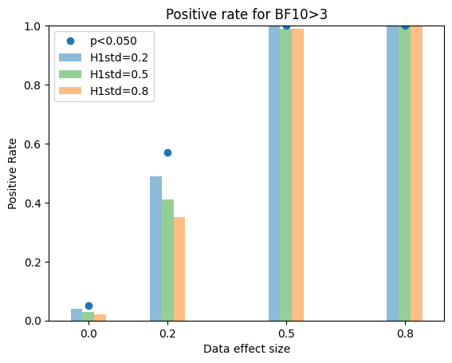

```python
effect_sizes =  np.array([0, 0.2, 0.5, 0.8])  # effect sizes in data
H1_mean = [0, 0, 0]
#H1_mean = [0.5, 0.5, 0.5]
H1_std = [0.2, 0.5, 0.8]  # variability under H1
num_samp = int(1e2) # reduce computation time
BF10_thr = 3

pr = np.full((len(effect_sizes), len(H1_std) + 1), np.nan)  # positive rate for BF10>thr
nr = pr.copy()  # negative rate for BF01>thr (BF10<1/thr)
for es, effect_size in enumerate(effect_sizes):
    pop_H1 = pop + effect_size
    samp = sample_pop(pop_H1, samp_size, num_samp)
    p = T2p_2tails(one_t(samp), samp_size-1)
    BF10 = np.full((num_samp, len(H1_std)), np.nan)
    for h1 in range(len(H1_std)):
        for s in range(num_samp):
            BF10[s, h1] = one_sample_BF(samp[:, s], H1_std[h1], H1_mean[h1])
    pr[es, 0]  = np.sum(p < alpha) / num_samp
    pr[es, 1:] = np.sum(BF10 > BF10_thr, axis=0) / num_samp
    nr[es, 1:] = np.sum(BF10 < 1 / BF10_thr, axis=0) / num_samp

txt = [f'p<{alpha:.3f}']
width =  np.array([0.03, 0.03, 0.03, 0.03])
bar_colours = ['tab:blue', 'tab:green', 'tab:orange']
plt.figure(); plt.plot(effect_sizes, pr[:, 0], 'o')
for h1 in range(len(H1_std)):
    txt.append(f'H1std={H1_std[h1]:.1f}')
    plt.bar(effect_sizes + (h1-1)*width, pr[:, h1+1], width, color = bar_colours[h1], alpha=0.5)
plt.title(f'Positive rate for BF10>{BF10_thr}')
plt.axis([-0.1, 0.9, 0, 1]); plt.legend(txt, loc='upper left'); plt.xticks(effect_sizes)
plt.xlabel('Data effect size'); plt.ylabel('Positive Rate');
```

The bars are for BFs with different priors for H1std, while the dots are for frequentist tests of H0. With this BF threshold of 3, the positive rates generally agree for the frequentist and Bayesian approaches, including when true effect size = 0, i.e., comparable false positive rates when there is no effect. Note that when the effect size is 0.2, the power for the BF approach increases as the prior std becomes tighter (when the prior mean is 0; see later). More important however is the positive rate when the BF favours H0:

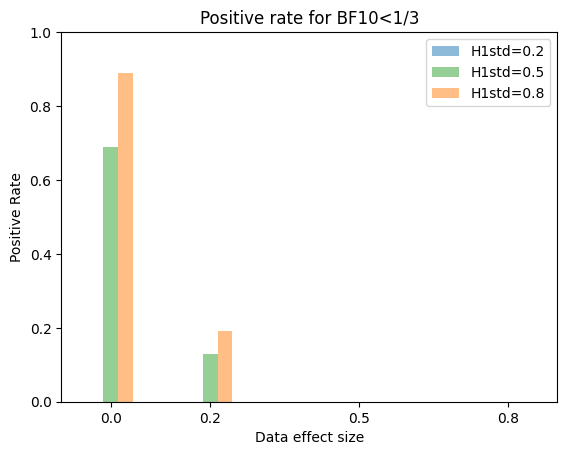

```python
plt.figure()
txt = []
for h1 in range(len(H1_std)):
    txt.append(f'H1std={H1_std[h1]:.1f}')
    plt.bar(effect_sizes + (h1-1)*width, nr[:, h1+1], width, color = bar_colours[h1], alpha=0.5)
plt.title(f'Positive rate for BF10<1/{BF10_thr}')
plt.axis([-0.1, 0.9, 0, 1])
plt.legend(txt, loc='upper right'); plt.xticks(effect_sizes)
plt.xlabel('Data effect size'); plt.ylabel('Positive Rate');
```

This is not something we can calculate with a p-value (though classical "equivalence tests" perform a similar function), but with BFs, we have a reasonable chance of concluding that the evidence favours the null when the null is true (effect size is 0). Note that there is also some chance that we will support H0 when the true effect size is non-zero, but smaller than we expected (i.e, when effect size is 0.2 but H1std>0.2). This is not necessarily unreasonable. In other words, BFs are sensitive to the size of the effect; not just whether it is present (non-zero) or absent (zero).

It is also informative to consider what happens as the sample size increases:

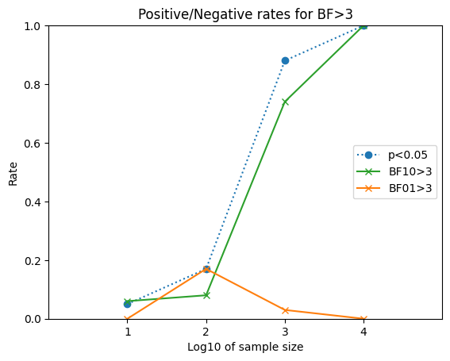

```python
effect_size = 0.1  # small effect size...
H1_mean     = 0
H1_std      = 0.3
samp_sizes = np.array([10, 100, 1000, 10000])
num_samp = int(1e2) # reduce computation time
BF10_thr = 3

pop_H1 = pop + effect_size
pr = np.full((len(samp_sizes), 3), np.nan)  # positive rate for BF10>thr
np.random.seed(1) # Initialise random seed
for s, samp_size in enumerate(samp_sizes):
    samp = sample_pop(pop_H1, samp_size, num_samp)
    p = T2p_2tails(one_t(samp), samp_size-1)
    BF10 = np.full(num_samp, np.nan)
    for n in range(num_samp):
        BF10[n] = one_sample_BF(samp[:, n], H1_std, H1_mean)
    pr[s,0] = np.sum(p < alpha) / num_samp
    pr[s,1] = np.sum(BF10 > BF10_thr, axis=0) / num_samp
    pr[s,2] = np.sum(BF10 < 1 / BF10_thr, axis=0) / num_samp

log_samp_sizes = np.log10(samp_sizes)
bar_colours = ['tab:blue', 'tab:green', 'tab:orange']
plt.figure();
plt.plot(log_samp_sizes, pr[:, 0], 'o:', color = bar_colours[0], label=f'p<{alpha:.2f}')
plt.plot(log_samp_sizes, pr[:, 1], 'x-', color = bar_colours[1], label=f'BF10>{BF10_thr}')
plt.plot(log_samp_sizes, pr[:, 2], 'x-', color = bar_colours[2], label=f'BF01>{BF10_thr}')
plt.title(f'Positive/Negative rates for BF>{BF10_thr}')
plt.axis([0, np.max(log_samp_sizes)+1, 0, 1]); plt.legend(loc='right'); plt.xticks(log_samp_sizes)
plt.xlabel('Log10 of sample size'); plt.ylabel('Rate');
```

Firstly, note that the power for the frequentist p-value increases monotonically with sample size. This is sometimes called the "fallacy of classical inference", i.e, with enough power, we can find any effect to be significant, even if trivially small (provided not zero).

Secondly, note that, as the sample size increases from 10 to 100, the rates of suprathreshold BF10 and BF01 both increase, as the confidence in the data value increases (i.e., fewer simulations have "moot" evidence of 1/3 < BFs < 3). But for sample sizes of 1000 and beyond, the rates of BF10 and BF01 exceeding the threshold reverse, such that the power for BF10 approaches 1 (like for the p-value), ie we can (correctly) detect that the true effect is non-zero.

So far H1 has assumed a mean of zero, but a non-zero probability of a mean different from zero (by virtue of H1_std>0). This is in contrast to H0, which assumes a zero probability of any value other than zero. Most "objective" priors assume a zero-mean. However, what happens when we have a theory or data that predicts a specific non-zero value, ie, H1_mean>0. This might be appropriate if we want to know whether an effect is "meaningful", i.e., big enough to affect behaviour in the real world. For example, finding a difference in reaction time between conditions of 5ms (or a difference in fMRI signal of 0.1%) might be irrelevant if we would not notice any difference less than 50ms in the real world (or if other brain regions would not respond to a brain region showing a change less than 1%). This ability to make inferences about the size of an effect, rather than just its presence/absece, is another attractive feature of Bayesian inference. However, the effect of sample size is again complicated:

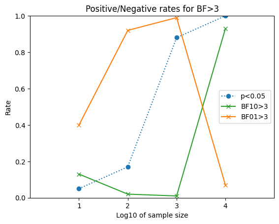

```python
effect_size = 0.1  # small effect size...
H1_mean     = 0.5  # yet expecting a bigger one...
H1_std      = 0.05 # ...with some confidence!
samp_sizes = np.array([10, 100, 1000, 10000])
num_samp = int(1e2) # reduce computation time
BF10_thr = 3

pop_H1 = pop + effect_size
pr = np.full((len(samp_sizes), 3), np.nan)  # positive rate for BF10>thr
np.random.seed(1) # Initialise random seed
for s, samp_size in enumerate(samp_sizes):
    samp = sample_pop(pop_H1, samp_size, num_samp)
    p = T2p_2tails(one_t(samp), samp_size-1)
    BF10 = np.full(num_samp, np.nan)
    for n in range(num_samp):
        BF10[n] = one_sample_BF(samp[:, n], H1_std, H1_mean)
    pr[s,0] = np.sum(p < alpha) / num_samp
    pr[s,1] = np.sum(BF10 > BF10_thr, axis=0) / num_samp
    pr[s,2] = np.sum(BF10 < 1 / BF10_thr, axis=0) / num_samp

log_samp_sizes = np.log10(samp_sizes)
bar_colours = ['tab:blue', 'tab:green', 'tab:orange']
plt.figure();
plt.plot(log_samp_sizes, pr[:, 0], 'o:', color = bar_colours[0], label=f'p<{alpha:.2f}')
plt.plot(log_samp_sizes, pr[:, 1], 'x-', color = bar_colours[1], label=f'BF10>{BF10_thr}')
plt.plot(log_samp_sizes, pr[:, 2], 'x-', color = bar_colours[2], label=f'BF01>{BF10_thr}')
plt.title(f'Positive/Negative rates for BF>{BF10_thr}')
plt.axis([0, np.max(log_samp_sizes)+1, 0, 1]); plt.legend(loc='right'); plt.xticks(log_samp_sizes)
plt.xlabel('Log10 of sample size'); plt.ylabel('Rate');
```

Now, for sample sizes from 10 to 1000, BFs will tend to support H0, in that a small effect in the data is more likely to come from the null than a prior that predicts a larger effect. Indeed, for samples sizes of 1000, we have an example of "Lindley's paradox", where the frequentist and Bayesian approaches completely diverge: i.e., you are very likely to find p<.05, i.e., reject the null, but also very likely to find BF01>3, i.e., support for the null. Only with even larger samples (10,000 here) does the situation reverse, where the confidence around the sample mean is so precise that it is nearly impossible to come from H0, even if it is also unlikely to have come from H1.

Thus Bayes Factors can exhibit complex behaviour as a function of the prior mean, prior spread and sample size, which can be difficult to intuit. Nonetheless, some believe them to be more principled, and they also facilitate some experimental designs, such as sequential designs, where we keep collecting more data until our BF threshold (for H1 or H0) is exceeded, which can be more efficient on average (at risk of slight increase in false positives).

*The frequentist says, “I don’t believe in priors.” The Bayesian answers, “You already have one - it’s just uniform and naïve."*

Others argue that frequentist p-values are more appropriate in many situations, e.g., by virtue of making fewer/weaker assumptions. Thus we return to the currently more conventional frequentist p-values for the rest of this notebook.

## Multiple Comparisons (correcting for many tests)

Sometimes we have multiple hypotheses that we wish to test. This is common in neuroimaging, eg for an ERP from a single channel, where we might have a 100 time points, or a 3D MRI image of 100x100x100 voxels. We'll only consider the 1D case here, with the number of tests given by "num_tests", though the logic here generalises to more than one dimension. So our data will now be a 3D matrix of sample_size (eg, number of participants) by num_tests (eg, number of voxels) by num_samp (number of experiments), which we're going to call "y".

Let's start by assuming that each test is independent, and H0 is true for all tests. We now wish to control the "family-wise error rate" (FWE) of at least one false positive across all the tests (to be less than alpha):

```
Family-wise error rate = 0.918
```

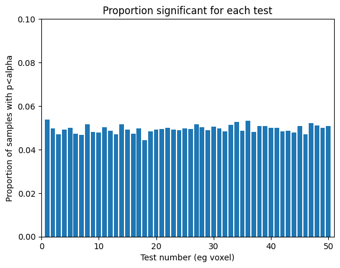

```python
samp_size = 20
num_tests = 50
num_samp = int(1e4)

y = np.full((samp_size, num_tests, num_samp), np.nan)
p = np.full((num_tests, num_samp), np.nan)
for s in range(num_samp):
    samp = sample_pop(pop, samp_size, num_tests)
    y[:, :, s] = samp  # store for below
    p[:, s] = T2p_higher(one_t(samp), samp_size - 1)

sig = (p < alpha)
fig, ax = plt.subplots(); ax.bar(range(1, num_tests + 1), np.sum(sig, axis=1) / num_samp)
ax.set_title('Proportion significant for each test')
ax.set_xlim(0, num_tests + 1); ax.set_ylim(0, 0.1);
ax.set_xlabel('Test number (eg voxel)'); ax.set_ylabel('Proportion of samples with p<alpha')
print(f'Family-wise error rate = {np.sum(np.any(sig, axis=0)) / num_samp:.3f}')
```

Although the FPR in each test is around 0.05, the FWE is much higher (i.e, likely that at least one test significant every time). One solution is to scale our threshold by the number of tests - the so-called "Bonferonni" correction:

```
Family-wise error rate = 0.051
```

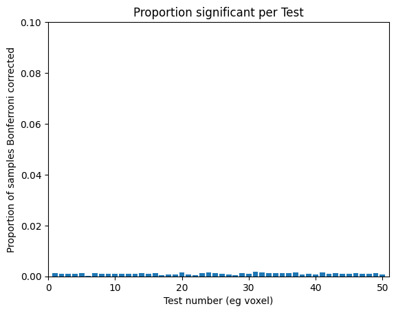

```python
alpha_cor = alpha / num_tests  # Bonferroni correction
sig = (p < alpha_cor)
plt.figure(); plt.bar(np.arange(1, num_tests+1), np.sum(sig, axis=1) / num_samp)
plt.title('Proportion significant per Test'); plt.axis([0, num_tests+1, 0, 0.1]);
plt.xlabel('Test number (eg voxel)'); plt.ylabel('Proportion of samples Bonferroni corrected')
print(f'Family-wise error rate = {np.sum(np.any(sig, axis=0)) / num_samp:.3f}')
```

*Interesting factoid: Carlo Bonferonni was a keen climber of glaciers, but we don't know whether he corrected his chance of death by the number of his climbs.*

This does control FWE at 5%. But in imaging, our tests are rarely independent. For example, ERP data are temporally autocorrelated across time, while MRI voxels are typically correlated across space. We can simulate this by smoothing our data (here with a simple, moving average of all values within a smooth_window for speed purposes):

```python
smooth_window = 20
smooth_window = np.ones(smooth_window)/smooth_window
smooth_y = np.empty_like(y)
for s in range(num_samp):
    for p in range(samp_size):
        smooth_y[p,:,s] = np.convolve(np.squeeze(y[p,:,s]), smooth_window, mode='same')
```

In this case, Bonferronni correction is too conservative:

```python
T = one_t(smooth_y)
p = T2p_higher(T, samp_size-1)
sig = (p < alpha_cor)
#plt.figure(); plt.bar(np.arange(1, num_tests+1), np.sum(sig, axis=1)/num_samp)
#plt.title('Proportion significant for each test'); plt.axis([0, num_tests+1, 0, 0.1])
#plt.xlabel('Test number (eg voxel)'); plt.ylabel('Proportion of samples Bonferonni corrected');
print(f'Family-wise error rate = {np.sum(np.any(sig, axis=0))/num_samp:.3f}')
```

```
Family-wise error rate = 0.017
```

### Permuting maximal statistics

Fortunately, permutation tests come in useful here. It turns out that if we calculate the maximum T-value across tests, and its null distribution from permuting the data many times, then the (1-alpha) percentile of this distribution of "maxT"s provides a threshold that controls FWE at alpha, as demonstrated below:

```
Maximum T threshold = 3.020
```

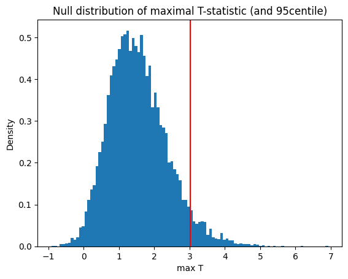

```python
y1 = np.squeeze(smooth_y[:,:,0])  # Calculate max T thr from one sample (experiment) for speed
num_rand = int(1e4)
maxT_null = np.full(num_rand, np.nan)
for r in range(num_rand):
    rs = np.sign(np.random.rand(samp_size) - 0.5)
    ry = y1 * np.tile(rs, (num_tests,1)).T  # must use same randomisation for all participants
    rT = one_t(ry)
    maxT_null[r] = np.max(rT)
maxT_null = np.sort(maxT_null)
maxT_thr = maxT_null[int(np.floor((1-alpha)*num_rand))]
pdf, bin_edges = np.histogram(maxT_null, bins=100, density=True)
plt.figure(); plt.bar((bin_edges[:-1] + bin_edges[1:]) / 2, pdf, width=bin_edges[1] - bin_edges[0])
plt.title(f'Null distribution of maximal T-statistic (and 95centile)')
plt.xlabel('max T'); plt.ylabel('Density')
plt.axvline(x=maxT_thr, color='r', label='threshold')
print(f'Maximum T threshold = {maxT_thr:.3f}')
```

(This is the basis of the "permute_maxT_one_sample" function below; note that it is important that each permutation is used for all voxels).

```python
def permute_maxT_one_sample(y, alpha=0.05, num_rand=10000):
    # Return vector of maxT thresholds for samp_size x num_tests matrix y
    samp_size = y.shape[0]
    num_tests = y.shape[1]
    r = np.sign(np.random.rand(samp_size, 1, num_rand) - 0.5)
    r = np.multiply(np.tile(y[:,:,np.newaxis],(1,1,num_rand)), np.tile(r, (1,num_tests,1)))   # must use same randomisation for all participants
    r = np.squeeze(np.mean(r, axis=0) / (np.std(r, axis=0) / np.sqrt(samp_size)))
    r = np.max(r, axis=0)
    if num_rand < 10000:
        maxT_thr = np.percentile(r, 100 * (1 - alpha))  # if insufficient permutations
    else:
        r = np.sort(r)
        maxT_thr = r[int(np.floor((1 - alpha) * num_rand))]
    return maxT_thr
```

Given this threshold for T-values, we can confirm the FWE is around .05:

```python
sig = (T > maxT_thr)
#plt.figure(); plt.bar(np.arange(1, num_tests+1), np.sum(sig, axis=1) / num_samp)
#plt.title('Proportion significant for each test'); plt.axis([0, num_tests+1, 0, 0.1])
#plt.xlabel('Test number (eg voxel)'); plt.ylabel('Proportion of samples with p<alpha')
print(f'Family-wise error rate = {np.sum(np.any(sig, axis=0)) / num_samp:.3f}')
```

```
Family-wise error rate = 0.048
```

Note that one should calculate maxT_thr for each new sample (experiment), but since our simulated experiments are identical, it is quicker to approximate this threshold for one dataset and apply to all experiments (cf. cluster size below).

We can now repeat for the unsmoothed case, confirming we still maintain FWE:

```python
y1 = np.squeeze(y[:,:,0]) # Take first experiment to calculate Tthr
maxT_thr = permute_maxT_one_sample(y1)
T = one_t(y)
sig = (T > maxT_thr)
#plt.figure(); plt.bar(np.arange(1, num_tests+1), np.sum(sig, axis=1)/num_samp)
#plt.title('Proportion significant for each test'); plt.axis([0, num_tests+1, 0, 0.1])
#plt.xlabel('Test number (eg voxel)'); plt.ylabel('Proportion of samples with p<alpha')
print(f'Family-wise error rate = {np.sum(np.any(sig, axis=0))/num_samp:.3f}')
```

```
Family-wise error rate = 0.040
```

Now let's add some signal (to the original unsmoothed data). If consider the tests as voxels in a 1D image for the moment, let's assume a large but "localised" effect for voxel index 30, plus a smaller but "distributed" effect across 10 voxels 10 to 19 inclusive (9-18 in python!):

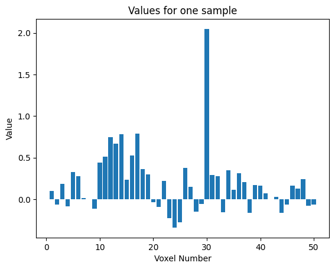

```python
y_signal = y.copy()
y_signal[:, 29, :] = y[:, 29, :] + 2
y_signal[:, 9:19, :] = y[:, 9:19, :] + 0.5
y1 = np.squeeze(y_signal[:, :, 0])  # Select example sample (first will do)
plt.figure(); plt.bar(np.arange(1, num_tests+1), np.mean(y1, axis=0));
plt.title('Values for one sample'); plt.xlabel('Voxel Number'); plt.ylabel('Value');
```

Let's see what the positive rates look like over lots of experiments:

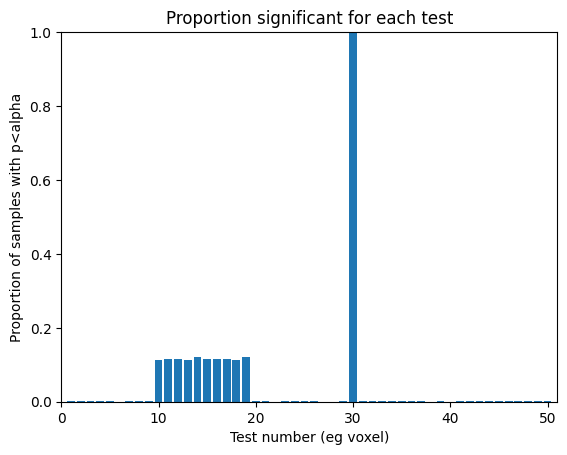

```python
maxT_thr = permute_maxT_one_sample(y1)
T = one_t(y_signal)
sig = (T > maxT_thr)
plt.figure(); plt.bar(np.arange(1, num_tests+1), np.sum(sig, axis=1) / num_samp)
plt.title('Proportion significant for each test')
plt.axis([0, num_tests+1, 0, 1]) # Note increase in y-axis scale
plt.xlabel('Test number (eg voxel)'); plt.ylabel('Proportion of samples with p<alpha')
#print(f'Family-wise positive rate = {np.sum(np.any(sig, axis=0)) / num_samp:.3f}')
```

We can detect the localised activation most of the time, but not the diffuse activation. One solution to the latter is to smooth the data, chosing a smoothing window that matches the extent of the diffuse cluster:

```python
smooth_window = 10
smooth_window = np.ones(smooth_window)/smooth_window
smooth_y_signal = np.empty_like(y_signal)
for s in range(num_samp):
    for p in range(samp_size):
        smooth_y_signal[p,:,s] = np.convolve(np.squeeze(y_signal[p,:,s]),smooth_window, mode='same')
```

Note that data may be intrinsically smooth, but we often want to explicitly smooth. One reason for this is to help justify the parametric assumptions of T-test, because smoothing effectively increases the amount of data being averaged, and so benefits from the CLT.

So what happens when we apply the same maximum T threshold to the smoothed data:

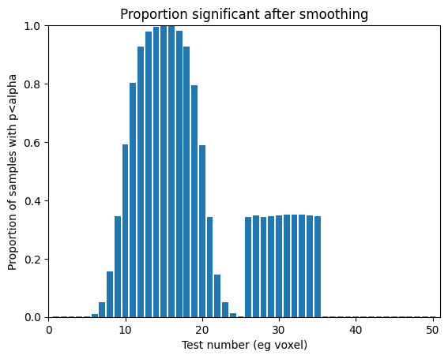

```python
y1 = np.squeeze(smooth_y_signal[:, :, 0])  # Select example sample (first will do)
maxT_thr = permute_maxT_one_sample(y1)
T = one_t(smooth_y_signal)
sig = (T > maxT_thr)
plt.figure(); plt.bar(np.arange(1, num_tests+1), np.sum(sig, axis=1) / num_samp)
plt.title('Proportion significant after smoothing'); plt.axis([0, num_tests+1, 0, 1]) # Note increase in y-axis scale
plt.xlabel('Test number (eg voxel)'); plt.ylabel('Proportion of samples with p<alpha')
#print(f'Family-wise positive rate = {np.sum(np.any(sig, axis=0)) / num_samp:.3f}')
```

You will notice that, while the power to detect voxels in the diffuse cluster has increased, that for the localised voxel has decreased, and its signal has in fact been smoothed into nearby voxels.

**Exercise: compare results with a smaller (eg 5) or bigger (eg 20) smoothing window (kernel) - do the results support the "matched filter theorem"?**

### Cluster-level Correction

But can we avoid "blurring" the data by smoothing, and still detect diffuse signals? Here permutation testing again helps us, because rather than permuting the maximal T value (which is suitable for detecting whether a single voxel is significant, sometimes called "peak" or "height" thresholding), we could permute the "cluster extent" - ie the number of contiguous voxels above some initial threshold.

We first need to determine the cluster size after an initial thresholding of voxels, and label each voxel with the size of the cluster in which it sits. This is done by the function "label_with_cluster_size":

```python
def label_with_cluster_size(x,thr):
    # label elements of x with size of cluster containing them, given threshold thr
    st = (x > thr).astype(int)
    cs = np.zeros_like(st)
    dp = np.diff(np.concatenate(([0], st, [0]))).nonzero()[0] # Find the positions where changes occur in st
    sp = dp[0::2] # Start points of segments
    ep = dp[1::2] # End points of segments
    dp = ep - sp  # Length of segments
    for c in range(len(dp)): # Fill cs with the lengths of segments
        cs[sp[c]:ep[c]] = dp[c]
    return cs
```

Here is an example, using p<.05 to define clusters:

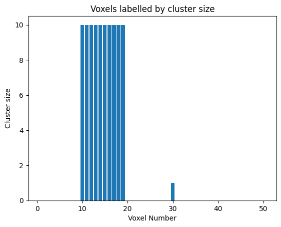

```python
from scipy.special import stdtrit as Tinv
y1 = np.squeeze(np.mean(y_signal,axis=2)) # mean of many samples of unsmoothed
cluster_defining_Tval = Tinv(samp_size-1, 1-alpha) # initial threshold to define clusters
cs = label_with_cluster_size(one_t(y1), cluster_defining_Tval)
plt.figure(); plt.bar(np.arange(1, num_tests+1), cs)
plt.title('Voxels labelled by cluster size'); plt.xlabel('Voxel Number'); plt.ylabel('Cluster size');
```

Note that the diffuse cluster is labelled with true size of 10 (because we have averaged out most of noise by averaging across many experiments), while the local activation is labelled correctly with size of 1 (and there might be additional spurious clusters, depending on random seed). We can now estimate the distribution of maximal cluster size:

```python
y1 = np.squeeze(y_signal[:,:,0])  # Calculate cluster thr from one sample (experiment) for speed
cs_null = np.empty(num_rand,dtype=int)
cluster_defining_Tval = Tinv(samp_size-1, 1-alpha)
for r in range(num_rand):
    rs = np.sign(np.random.rand(samp_size) - 0.5)
    ry = y1 * np.tile(rs, (num_tests,1)).transpose()  # must use same randomisation for all participants
    rT = one_t(ry)
    cs_null[r] = np.max(label_with_cluster_size(rT, cluster_defining_Tval))
cs_null = np.sort(cs_null)
cs_thr  = cs_null[int(np.floor((1-alpha)*num_rand))]
print(f'Minimum extent for cluster-level for FWE correction = {cs_thr}')
```

```
Minimum extent for cluster-level for FWE correction = 2
```

Thus clusters of at least 2 contiguous voxels are unlikely by chance. Note that the initial threshold (here the T-value corresponding to p<.05 uncorrected) will affect extent threshold. We can use this to do "cluster-level correction", as done in the "permute_cluster_metric_one_sample" function below (with "size" as the metric):

```python
def permute_cluster_metric_one_sample(ys,thrs,alpha=0.05,num_rand=int(1e4),metric='size'):
    # Return vector of cluster size thresholds for samp_size x num_tests matrix y
    # given height threshold(s) (thrs)
    samp_size = ys.shape[0]
    num_tests = ys.shape[1]

    rs = np.sign(np.random.rand(samp_size, num_rand) - 0.5)

    null_dist = np.full(num_rand, np.nan)
    match metric:
        case 'size':
            for b in range(num_rand):
                r = ys * np.tile(rs[:,b],(num_tests, 1)).transpose()
                r = one_t(r)
                cs = label_with_cluster_size(r,thrs[0])
                null_dist[b] = np.max(cs)
        case 'TFCE':
            for b in range(num_rand):
                r = ys * np.tile(rs[:,b],(num_tests, 1)).transpose()
                r = one_t(r)
                cm = label_with_cluster_TFCE(r,thrs)
                null_dist[b] = np.max(cm)
        case _:
            error('Unknown metric')

    if num_rand < 10000:
        cluster_thr = np.percentile(null_dist, 100 * (1 - alpha))  # if insufficient permutations
    else:
        null_dist = np.sort(null_dist)
        cluster_thr = null_dist[int(np.floor((1 - alpha) * num_rand))]

    return cluster_thr
```

We can now see how this cluster threshold of 2 adjacent voxels affects power (though with only 50 voxels and hence small range of cluster sizes, we could also lower the cluster-defining threshold to get a larger range of cluster sizes):

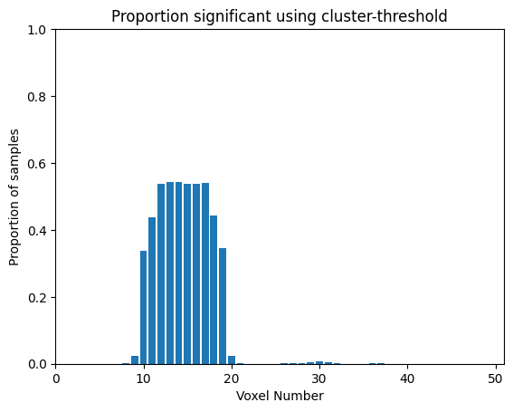

```python
num_samp = int(1e4) # reduce if need to speed up
#cluster_defining_Tval = 0.5 # if want to reduce initial cluster-defining height threshold
cs = np.empty([num_samp,num_tests])
cs_thr = np.empty(num_samp)
for s in range(num_samp):
    ys = np.squeeze(y_signal[:,:,s])
    T = one_t(ys)
    if s==0: # Faster to estimate from one sample, since all samples asymptotically equivalent
        cs_thr[s] = permute_cluster_metric_one_sample(ys,np.array([cluster_defining_Tval]),alpha,num_rand,'size')
    else:
        cs_thr[s] = cs_thr[0]
    #    cs_thr[s] = permute_cluster_metric_one_sample(ys,np.array([cluster_defining_Tval]),alpha,num_rand,'size')
    cs[s,:] = label_with_cluster_size(T,cluster_defining_Tval)
    cs[s,:] = (cs[s,:] > cs_thr[s])
plt.figure(); plt.bar(np.arange(1, num_tests+1), np.sum(cs, axis=0) / num_samp)
plt.title('Proportion significant using cluster-threshold')
plt.axis([0, num_tests+1, 0, 1])
plt.xlabel('Voxel Number'); plt.ylabel('Proportion of samples');
pr = np.sum(np.any(cs, axis=1)) / num_samp
#print(f'Family-wise positive rate using cluster-threshold = {pr:.3f}')
```

Notice that the diffuse cluster is now detected reasonably well, but the localised one is not (cf. the case for corrected peak threshold earlier). We are basically trading-off statistical sensitivity for localising power: with the cluster-level correction, we are more sensitive (to clusters), but are unable to localise within clusters (ie cannot claim a particular voxel within a cluster is significant). The power is not as high as when smoothing the data previously (since smoothing reduces noise by pooling over nearby voxels), but at least we have fewer false positives (<5%) for voxels outside the true activation (compare voxels 9 and 20 with smoothed results above).

**Exercise: Here we have applied to the unsmoothed data with signal, but you can see what happens for the smoothed data, smooth_y_signal, or the unsmoothed data with no signal, y (to check FWE), or what happens as you change the initial cluster-defining height threshold (e.g, making lower as in commented code above). You can also compare results when the threshold is calculated for each sample separately (by uncommenting the line after "else" above), and examine the range of extent thresholds resulting (cs_thr), but it will take a long time...**

Note that there are parametric versions that correct FWE for peak or cluster extent using "Random Field Theory" but they are beyond the present scope. They also make more assumptions, such as requiring data to have a minimal smoothness, and a sufficiently stringent initial threshold for defining cluster size.

### Threshold-free cluster enhancement (TFCE)

Given above, how about permuting a property that includes a contribution from both the height and extent of each cluster, such as the cluster "mass" (e.g, the product of height and extent of each cluster in the current 1D example)? Note also that the results from the above cluster-level correction still depend on the initial height threshold that defines the clusters. "Threshold-free Cluster Enhancement" (TFCE) is a popular method that combines these two ideas, by integrating cluster masses across a range of thresholds. To use it, we first need to define a function for calculating cluster mass, which takes a range of thresholds (and parameters H and E that can be further optimised):

```python
def label_with_cluster_TFCE(x,thrs,H=1,E=1):
    # label elements of x with cluster "mass", given range of thresholds thrs
    # Note E=0.5, H=2 optimal from Nichols paper
    TFCE = np.zeros_like(x)
    for thr in thrs:
        st = (x > thr).astype(int)
        dp = np.diff(np.concatenate(([0], st, [0]))).nonzero()[0] # Find the positions where changes occur in st
        sp = dp[0::2] # Start points of segments
        ep = dp[1::2] # End points of segments
        dp = ep - sp  # Length of segments
        for c in range(len(dp)): # Fill cm with the masses of segments
            cm = dp[c]**E * x[sp[c]:ep[c]]**H
            TFCE[sp[c]:ep[c]] = TFCE[sp[c]:ep[c]] + np.sum(cm)
    return TFCE
```

Now we can examine its sensitivity to both the diffuse and focal signal in our example... (Note that we use a set of 3 fixed cluster-defining thresholds, but you could define a set based on 3 (or more) percentiles of the range of T-values, which would adjust thresholds to the SNR in the data)

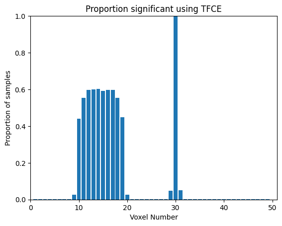

```python
p_range = np.array([0.05, 0.01, 0.001]) # range of cluster-defining p-values (can add more, but will take more time)
T_range = Tinv(samp_size-1, 1-p_range)  # ...equivalent T-values

cm = np.empty([num_samp,num_tests])
cm_thr = np.empty(num_samp)
for s in range(num_samp):
    ys = np.squeeze(y_signal[:,:,s])
    T = one_t(ys)
    if s==0: # Faster to estimate from one sample, since all samples asymptotically equivalent
        cm_thr[s] = permute_cluster_metric_one_sample(ys,T_range,alpha,num_rand,'TFCE')
    else:
        cm_thr[s] = cm_thr[0]
    #    cm_thr[s] = permute_cluster_metric_one_sample(ys,T_range,alpha,num_rand,'TFCE')
    cm[s,:] = label_with_cluster_TFCE(T,T_range)
    cm[s,:] = (cm[s,:] > cm_thr[s])
plt.figure(); plt.bar(np.arange(1, num_tests+1), np.sum(cm, axis=0) / num_samp)
plt.title('Proportion significant using TFCE'); plt.axis([0, num_tests+1, 0, 1]);
plt.xlabel('Voxel Number'); plt.ylabel('Proportion of samples');
pr = np.sum(np.any(cm, axis=1)) / num_samp
#print(f'Family-wise positive rate using TFCE = {pr:.3f}')
```

Now we are detecting both the diffuse activation and the localised activation with reasonable power, which is neat!

**Exercise: You can also play with H and E to optimise to extent or height, or if you want a more advanced exercise, you could modify the code above to handle two-tailed tests, ie possible deactivations (hint: you need to permute clusters separately for each tail).**

## False Discovery Rate (FDR)

```
Number of discoveries using FDR = 3
```

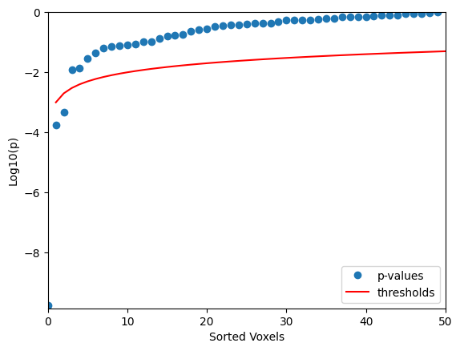

```python
y1 = np.squeeze(y_signal[:,:,1])
#y1 = np.squeeze(smooth_y_signal[:,:,0])
#y1 = np.squeeze(smooth_y[:,:,0])     # No true positives
#y1 = np.squeeze(smooth_y[:,:,0])+10  # All true positives
T = one_t(y1)
p = T2p_higher(one_t(y1), samp_size-1)
ps = np.sort(p) + np.finfo(float).eps # eps added to avoid log(0) below
thr = alpha * (np.arange(num_tests)+1) / num_tests  # FDR thresholds
st = np.where(ps < thr)[0]
plt.figure(); plt.plot(np.log10(ps), 'o');
plt.ylabel('Log10(p)'); plt.xlabel('Sorted Voxels');
plt.plot(np.arange(1, num_tests+1), np.log10(thr), 'r-')
plt.axis([0, num_tests, np.log10(np.min([ps, thr]))-0.1, 0]);
plt.legend(['p-values', 'thresholds', 'FDR threshold'], loc='lower right');
print(f'Number of discoveries using FDR = {len(st):d}')
```

Note that FDR defaults to Bonferroni if there are no true positives, and defaults to uncorrected alpha if they are all true positives. Note also that this method is similar to the Holm-Bonferonni "step-up" procedure, except any tests that survive their threshold are included in FDR, rather than stopping as soon as a test is non-significant.

```
Mean error rate in non-active voxels under FWE = 0.013
Mean error rate in non-active voxels under FDR = 0.173
```

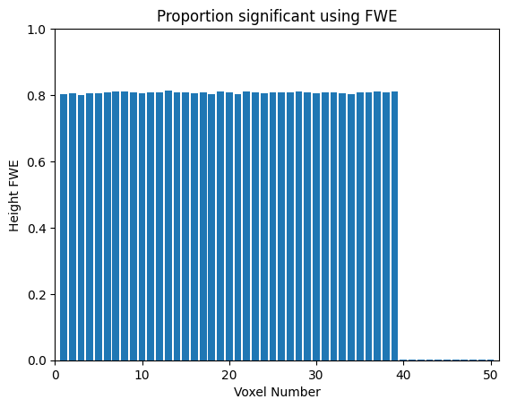

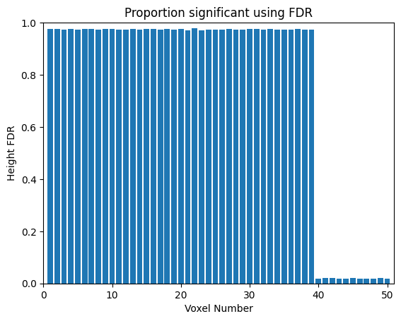

```python
y_signal = y.copy()
y_signal[:,0:39,:] = y[:,0:39,:] + 1 # Add signal to first 40 voxels

# FWE correction
y1 = np.squeeze(y_signal[:,:,0])  # Select example sample for max T threshold
maxT_thr = permute_maxT_one_sample(y1)
T = one_t(y_signal)
sig = (T > maxT_thr).T
plt.figure(); plt.bar(np.arange(1, num_tests+1), np.sum(sig, axis=0) / num_samp)
plt.title('Proportion significant using FWE'); plt.axis([0, num_tests+1, 0, 1])
plt.xlabel('Voxel Number'); plt.ylabel('Height FWE');
pr = np.sum(np.any(sig[:,40:], axis=1)) / num_samp
print(f'Mean error rate in non-active voxels under FWE = {pr:.3f}')

# FDR correction
p = T2p_higher(T, samp_size-1)
sig = np.zeros_like(p).T
for s in range(num_samp):
    ps  = np.sort(p[:, s], axis = 0)
    ind = np.argsort(p[:, s], axis = 0)
    st  = np.where(ps < thr)[0] # Using same threshold as above
    if len(st) > 0:
        max_st = np.max(st)
        sig[s,ind[0:max_st]] = 1
plt.figure(); plt.bar(np.arange(1, num_tests+1), np.sum(sig, axis=0) / num_samp)
plt.title('Proportion significant using FDR'); plt.axis([0, num_tests+1, 0, 1]);
plt.xlabel('Voxel Number'); plt.ylabel('Height FDR');
pr = np.sum(np.any(sig[:,40:], axis=1)) / num_samp
print(f'Mean error rate in non-active voxels under FDR = {pr:.3f}')
```

Note FDR leads to more true positives for the first 40 voxels. However, this comes at the cost of increased false positives in non-active voxels (the remaining 10 voxels). This is because FDR controls the number of false positives as a proportion (eg 5%) of voxels declared significant, rather than as a proportion of tests performed (like FWE). So the more active voxels there are in one part of the image, the more false positives are likely in other parts of the image where there is no signal. Thus it is really a qualitatively different type of inference, and some would argue that maintaining the traditional FWE is more important.

Finally, note that all the methods above are designed for (safe) inferences on "mass univariate" tests. This is appropriate if the aim is localisation in space or time, but if the aim is to detect signal anywhere, there are much more sensitive "multivariate" tests like PLS/CCA that leverage on covariance between tests.

## Two-sample T-tests

We now turn to two-sample tests. Here H0 is often that the means of (whatever generated) two samples are equal. We start with the easy case of a "paired" test, where two "conditions" are measured on the same people, i.e., each person contributes two values (sometimes called a "repeated measure"). In this case, we can simply calculate the difference between these two values for each person, and run a one-sample test on these "difference scores". In the context of a permutation test, we would be randomly swapping the two values for each person, hence the basis for randomising the sign of the (difference) values in the one-sample test examples above.

More interesting is the "unpaired" (or "independent samples") case, when the samples (groups) are drawn from two populations of different people, and we have one value per person. Under H0 that these populations are identical, we could randomly assign people to either group. This is called "exchangeability"; in the unpaired case, all values are exchangeable, whereas in the paired case, only values within the same person are exchangeable (exchangeability is normally a condition of randomisation tests). If there are N1 people in sample of first population, and N2 in second sample, then for a permutation test, there are (N1+N2)!/(N1!N2!) permutations, which quickly gets very large as N1 and/or N2 increase. Nonetheless, it is normally sufficient to sample ~1e4 to estimate a p-value, as done in the function "randomise_two_samples" below.

```python
def randomise_two_samples(y, num_rand=10000, two_tailed=False, rand_method='permute', property='mean'):
    # Estimate probability that some property of second independent sample is greater (or smaller, if two-tailed)
    # than that of a first sample, using a certain randomisation method.

    if property == 'mean':
        property_lambda = lambda y: np.mean(y[1],axis=0) - np.mean(y[0],axis=0)
    elif property == 'tstat':
        pool_var        = lambda y: ((y[0].shape[0]-1)*np.var(y[0], ddof=1) + (y[1].shape[0]-1)*np.var(y[1], ddof=1)) / (y[0].shape[0] + y[1].shape[0] - 2)
        property_lambda = lambda y: (np.mean(y[1],axis=0) - np.mean(y[0],axis=0)) / np.sqrt(pool_var(y) * (1/y[0].shape[0] + 1/y[1].shape[0]))
 #       property_lambda = lambda y: (np.mean(y[1],axis=0) - np.mean(y[0],axis=0)) / np.sqrt(np.var(y[0], ddof=1)/y[0].shape[0] + np.var(y[1], ddof=1)/y[1].shape[0])

    if rand_method == 'permute':
        select = lambda x, num_rand: x[np.random.rand(x.shape[0], num_rand).argsort(axis=0)] # faster than np.shuffle
    elif rand_method == 'bootstrap':
        select = lambda x, num_rand: x[np.ceil(np.random.rand(x.shape[0], num_rand) * (x.shape[0] - 1)).astype(int)]
    else:
        raise ValueError(f'Randomisation method {rand_method} unknown')

    samp_size = np.array([2,1])
    samp_size[0] = y[0].shape[0]
    yc = np.concatenate(y, axis=0)
    num_samp = yc.shape[1]

    prop = np.full((num_samp), np.nan)
    for s in range(num_samp):
        actual_value = property_lambda([y[0][:,s], y[1][:,s]])
        ys = yc[:, s]
        yr = select(ys, num_rand)
        yp = [yr[:samp_size[0]], yr[samp_size[0]:]] # convert back into two samples
        rand_dist = property_lambda(yp)
        if two_tailed:
            prop[s] = (np.sum(np.abs(rand_dist) >= np.abs(actual_value)) + 1) / (num_rand + 1)
        else:
            prop[s] = (np.sum(rand_dist >= actual_value) + 1) / (num_rand + 1)

    if num_samp == 1:
        prop = prop[0]

    return prop
```

Alternatively, we can also use a parametric approach. There are several versions of the parametric version of the two-sample T-test, but we can start with a standard one that assumes equal variance in both groups:

```python
pool_var = lambda y: ((y[0].shape[0]-1)*np.var(y[0], ddof=1) + (y[1].shape[0]-1)*np.var(y[1], ddof=1)) / (y[0].shape[0] + y[1].shape[0] - 2)
two_t = lambda y: (np.mean(y[1],axis=0) - np.mean(y[0],axis=0)) / np.sqrt(pool_var(y) * (1/y[0].shape[0] + 1/y[1].shape[0]))
```

The first "pool_var" function above pools the variance across both groups, weighted by their respective sizes. This pooled estimate of variance is then used in the second function "two_t", in which the numerator is the difference of group means, while the denominator is equivalent to the pooled standard error. The p-value can then be calculated from the same T-distribution with dfs equal to the total number across both groups minus 2 (the 2 dfs used for estimating the mean within each group).

Assuming equal group sizes, we can plot power curves for two-tailed, unpaired T-tests as a function of group sizes:

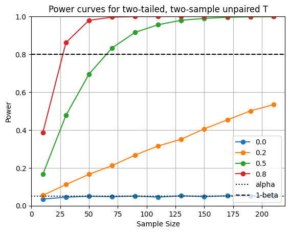

```python
num_rand = int(1e4)
num_samp = int(1e4) # Reduce if uncomment randomisation below and want to save time
samp_sizes = np.arange(10, 220, 20) # Number per group
effect_sizes = [0, 0.2, 0.5, 0.8]
fig, ax = plt.subplots(); ax.set_title('Power curves for two-tailed, two-sample unpaired T');
ax.set_xlabel('Sample Size'); ax.set_ylabel('Power');
ax.set_xlim(min(samp_sizes)-10, max(samp_sizes)+10); ax.set_ylim(0, 1); ax.grid(True)

pr = np.full((len(samp_sizes), len(effect_sizes)), np.nan)
for es, effect_size in enumerate(effect_sizes):
    pop_H1 = pop + effect_size
    for s, samp_size in enumerate(samp_sizes):
        df = 2*samp_size - 2
        y1 = sample_pop(pop, samp_size, num_samp)
        y2 = sample_pop(pop_H1, samp_size, num_samp)
        p = T2p_2tails(two_t([y1, y2]), df)
        pr[s, es] = np.sum(p < alpha) / num_samp

for es, effect_size in enumerate(effect_sizes):
    ax.plot(samp_sizes, pr[:, es], 'o-', label=f'{effect_size:.1f}')
ax.axhline(y=alpha, linestyle=':', color='k', label='alpha');
ax.axhline(y=0.8, linestyle='--', color='k', label='1-beta');
ax.legend(loc='lower right');
```

Note that groups of ~70 are needed to get 80% power with a medium effect size, which means testing 140 people in total. This is quite a bit more than the ~30 needed for the one-sample test above (which is equivalent to a paired, two-sample T-test, demonstrating the increased power of repeated-measures designs). Note also that many imaging studies use relatively small samples of ~20 when comparing groups, which would entail power of only ~30%...

**Exercise: Calculate power curves after controlling FWE across a large number of tests. Imagine for example you have an fMRI study with 1e6 voxels (and no a priori idea where you might find an effect): even allowing for an intrinsic smoothness in the data (such that you might only have 1e3 "resels" - "resolvable elements" - for Bonferonni correction), what are chances of traditional fMRI group sizes finding a true effect somewhere in the brain while controlling FWE?**

### Unequal group sizes and pooled variance estimates

We can also plot what happens when the total number of participants is fixed, but the ratio of group sizes varies:

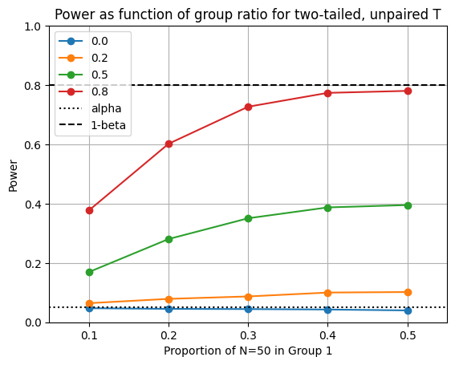

```python
tot_samp_size = 50
df = tot_samp_size - 2
group_ratio = np.arange(0.1, 0.51, 0.1) # Proportion in Group 1
fig, ax = plt.subplots();
ax.set_title('Power as function of group ratio for two-tailed, unpaired T'); ax.set_xlabel(f'Proportion of N={tot_samp_size:d} in Group 1')
ax.set_ylabel('Power'); ax.set_xlim(0.05, 0.55); ax.set_ylim(0, 1); ax.grid(True)
#num_samp = int(1e3) # Reduce if uncomment randomisation below and want to save time

pr = np.full((len(group_ratio), len(effect_sizes)), np.nan)
for es, effect_size in enumerate(effect_sizes):
    pop_H1 = pop + effect_size
    for s, ratio in enumerate(group_ratio):
        samp_size1 = round(ratio * tot_samp_size)
        samp_size2 = tot_samp_size - samp_size1
        y1 = sample_pop(pop, samp_size1, num_samp)
        y2 = sample_pop(pop_H1, samp_size2, num_samp)
        p = T2p_2tails(two_t([y1, y2]), df)
        #p = randomise_two_samples([y1, y2], num_rand, two_tailed=True, property='mean')
        #p = randomise_two_samples([y1, y2], num_rand, two_tailed=True, property='tstat')
        pr[s, es] = np.sum(p < alpha) / num_samp

for es, effect_size in enumerate(effect_sizes):
    ax.plot(group_ratio, pr[:, es], 'o-', label=f'{effect_size:.1f}')
ax.axhline(y=alpha, linestyle=':', color='k', label='alpha');
ax.axhline(y=0.8, linestyle='--', color='k', label='1-beta');
ax.legend(loc='upper left');
```

Note that power decreases as the groups become more unbalanced, though FPR is still controlled (for the T-test).

You can also try permutation testing of either the mean or the T-statistic itself, by uncommenting the relevant lines above (though it will take a long time to run), and should get similar results.

### Inhomogeniety of variance: correcting dfs (Welch)

However the variance pooling used by the standard T-test fails when the variance of one group differs from the other. Such "inhomogeniety" of variance is a special case of the more general problem of "nonpshericity" discussed in the GLM section below.

Indeed, the combination of unequal variance and unequal group sizes is particularly serious for the standard T-test, and can lead to an inflated FPR as we show below. One solution is called Welch's T-test, which does not pool the variance, and reduces the dfs to a fraction of original dfs (an example of Sattherthwaite approximation, to which we will return in the GLM section below). This correction is implemented in the function two_sample_T below:

```python
def two_sample_T(y, type='welch'):
    # Testing mean of Group 2 > mean of Group 1

    N = [y[0].shape[0], y[1].shape[0]]
    if 1 in N:
        type = 'pooled'
    dm = np.mean(y[1],axis=0) - np.mean(y[0],axis=0)
    v1 = np.var(y[0], ddof=1, axis=0)
    v2 = np.var(y[1], ddof=1, axis=0)
    df = sum(N) - 2
    df = np.repeat(df, y[0].shape[1])
    if type == 'unpooled':
        T = dm / np.sqrt(v1/N[0] + v2/N[1])
    elif type == 'pooled':
        sp = ((N[0]-1)*v1 + (N[1]-1)*v2) / df
        T = dm / np.sqrt(sp * (1/N[0] + 1/N[1]))
    elif type == 'welch':
        T = dm / np.sqrt(v1/N[0] + v2/N[1])
        sp = (v1/N[0])**2 / (N[0]-1) + (v2/N[1])**2 / (N[1]-1)
        df = (v1/N[0] + v2/N[1])**2 / sp
    return T, df
```

Using this, we can illustrate the inhomogeniety of variance problem (for an unbalanced designs) below:

```
Difference in mean = 0.0
		Variance ratio = 0.5
				Pooled T	(df=48.00),	PR=0.251
				Welchs T	(df=4.48),	PR=0.054
		Variance ratio = 1.0
				Pooled T	(df=48.00),	PR=0.050
				Welchs T	(df=6.03),	PR=0.053
		Variance ratio = 2.0
				Pooled T	(df=48.00),	PR=0.001
				Welchs T	(df=12.27),	PR=0.058
Difference in mean = 0.8
		Variance ratio = 0.5
				Pooled T	(df=48.00),	PR=0.719
				Welchs T	(df=4.46),	PR=0.279
		Variance ratio = 1.0
				Pooled T	(df=48.00),	PR=0.384
				Welchs T	(df=5.96),	PR=0.301
		Variance ratio = 2.0
				Pooled T	(df=48.00),	PR=0.033
				Welchs T	(df=12.19),	PR=0.269
```

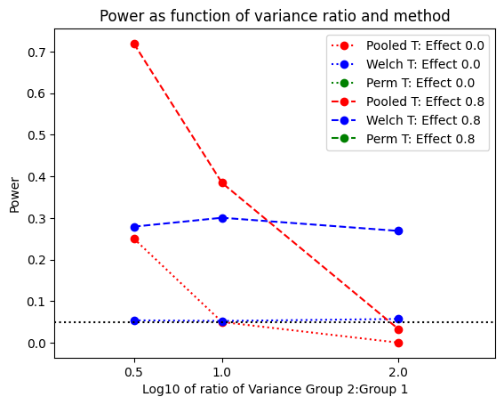

```python
samp_sizes = [5, 45]     # At least one small group
diff_means = [0, 0.8]    # Difference in means
var_ratios = [0.5, 1, 2] # Ratio of variances in Group 2 vs Group 1
num_samp = int(1e4) # reduce if need speed up permutation test below
y = [None, None]
pr = np.full((len(diff_means), len(var_ratios), 3), np.nan) # 3rd argument is method
for es, diff_mean in enumerate(diff_means):
    print(f'Difference in mean = {diff_mean:.1f}')
    for vr, var_ratio in enumerate(var_ratios):
        print(f'\t\tVariance ratio = {var_ratio:.1f}')
        pop_2 = pop * var_ratio + diff_mean
        y[0] = sample_pop(pop,   samp_sizes[0], num_samp)
        y[1] = sample_pop(pop_2, samp_sizes[1], num_samp)
        # Pooled T-test
        T, df = two_sample_T(y, 'pooled')
        p = T2p_2tails(T, df)
        pr[es, vr, 0] = np.sum(p < alpha)/num_samp
        print(f'\t\t\t\tPooled T\t(df={np.mean(df):.2f}),\tPR={pr[es, vr, 0]:.3f}')
        # Welch's T-test
        T, df = two_sample_T(y, 'welch')
        p = T2p_2tails(T, df)
        pr[es, vr, 1] = np.sum(p < alpha)/num_samp
        print(f'\t\t\t\tWelchs T\t(df={np.mean(df):.2f}),\tPR={pr[es, vr, 1]:.3f}')
        # Permutation test
        #p = randomise_two_samples(y, num_rand, two_tailed=True, property='mean')
        ##p = randomise_two_samples(y, num_rand, two_tailed=True, property='tstat')
        #pr[es, vr, 2] = np.sum(p < alpha)/num_samp
        #print(f'\t\t\t\tPermuted\t(df=N/A),\tPR={pr[es, vr, 2]:.3f}')
fig, ax = plt.subplots(); ax.set_title(f'Power as function of variance ratio and method')
markers = ['ro:', 'ro--', 'bo:', 'bo--', 'go:', 'go--']
labels = []
for q, diff_mean in enumerate(diff_means):
    ax.plot(var_ratios, pr[q, :, 0], markers[q], label=f'Pooled T: Effect {diff_mean:.1f}');
    ax.plot(var_ratios, pr[q, :, 1], markers[q+2], label=f'Welch T: Effect {diff_mean:.1f}');
    ax.plot(var_ratios, pr[q, :, 2], markers[q+4], label=f'Perm T: Effect {diff_mean:.1f}');
ax.axhline(y=alpha, color='k', linestyle=':'); labels.append('alpha')
ax.legend(loc='upper right'); ax.set_xlim(0.05, 2.55); #ax.set_ylim(0, 0.8)
ax.set_xticks(var_ratios); ax.set_xlabel('Log10 of ratio of Variance Group 2:Group 1'); ax.set_ylabel('Power'); plt.show()
```

When there is no effect, the FPR for the pooled T-test is too high when the smaller group is more variable, and too low when the larger group is more variable, whereas the Welch correction (notice the reduced, fractional dfs) maintains FPR close to correct alpha level in all cases. There is a price of this correction though: when variances are homogeneous (ratio of 1), the power to detect a true effect is reduced with the Welch correction (i.e, it is conservative).

If you uncommment the permutation tests, it will take a while to run, but you should see that FPR is also no longer controlled (even for a pivotal statistic like the pooled variance, two-sample T-statistic) for the cases of unequal variance. This is because the exchangeability criterion is now violated - we cannot simply swap participants between the two groups because the groups are drawn from different populations (differing in their variance). These are situations where parametric tests offer advantages over randomisation testing, in having mathematical (asymptotic) tools that adjust for differences between population distributions (like the Welch correction). Having said that, you could still permute a Welch-corrected T-statistic (not implemented in above randomise_two_samples function) to estimate the p-value.

## The General Linear Model (GLM)

The T-test is a special case of the General Linear Model (GLM). The GLM is normally expressed as **y = XB+e**, where **y** is a vector of all data (concatenated across groups), **X** is a matrix ("design matrix") that specifies the model of the data, **B** ("Betas") is a vector of the model parameters to be estimated, and **e** is random error, assumed to be drawn independently from a zero-mean Gaussian (with std estimated when GLM is fit). It can also be written as a set of simultaneous equations y_i = B1 *x* x1_i + B2 *x* x2_i... + e_i, for ith observation. Note that, for a unique solution, there should be more datapoints than predictors in the model, i.e. X must be a "tall" matrix with more rows than columns.

### GLM for unpaired T-test

So if we stick with the example of a two-sample, unpaired T-test:

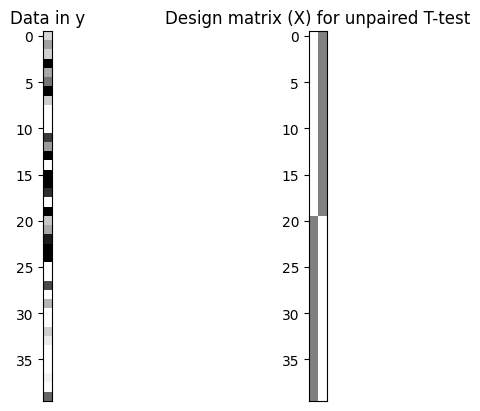

```python
np.random.seed(2) # Initialise random seed
N = [20, 20]
yg = [None,None]
yg[0] = sample_pop(pop, N[0], 1)
yg[1] = sample_pop(pop, N[1], 1) + 0.5
y = np.concatenate(yg, axis=0)
X = np.concatenate([np.ones((N[0], 1)), np.zeros((N[1], 1))], axis=0)
X = np.concatenate([X, np.concatenate([np.zeros((N[0], 1)), np.ones((N[1], 1))], axis=0)], axis=1)
plt.figure(); plt.subplot(1, 2, 1)
plt.imshow(y, cmap='gray', vmin=-1, vmax=1)
plt.title('Data in y'); plt.xticks([]);
plt.subplot(1, 2, 2); plt.imshow(X, cmap = 'gray', vmin=-1, vmax=1)
plt.title('Design matrix (X) for unpaired T-test'); plt.xticks([]);
```

The first column of X is a binary, indicator variable that codes which data points come from Group 1, while the second column codes which are from Group 2.

This model can be fit to the data by minimising the squared residuals - so-called "ordinary least squares" (OLS) estimation. Some simple maths shows that this implies that the parameters can be estimated by multiplying the data by the (pseudo)inverse of the design matrix:

```python
B = np.linalg.pinv(X) @ y  # OLS estimate of Betas
print(f'Parameter (Beta) estimates = {B.T[0]}')
```

```
Parameter (Beta) estimates = [-0.00354831  0.55715009]
```

where "B" are estimates of the true parameters. If you examine "pinv(X)", you'll see that it is just estimating the mean for each group in this case. (Technically, one should pre-multiply y by inv(X'*X)*X'- an expression derived from minimising e^2 with respect to B; hence the "least squares" solution - but pinv(X) is more robust for rank-deficient matrices.)

We can then reconstruct the model fit, the residuals, and estimate the std of the error, given the df:

```
Estimated std of error = 1.35
```

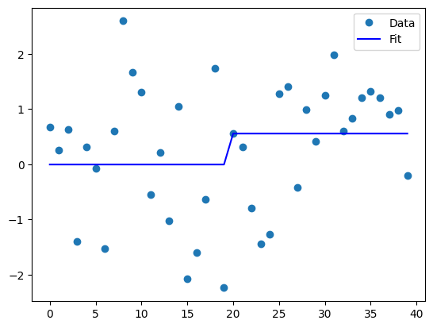

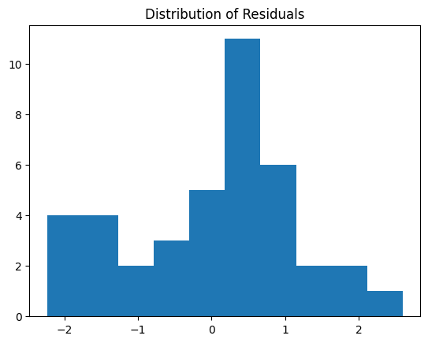

```python
Y = X @ B  # Reconstruct fitted response
r = y - Y  # Residuals
fig, ax = plt.subplots(); ax.plot(y, 'o'); ax.plot(Y, '-b'); ax.legend(['Data', 'Fit']);
fig, ax = plt.subplots(); ax.hist(r); ax.set_title('Distribution of Residuals');  # residuals consistent with Gaussian error
df = len(y) - np.linalg.matrix_rank(X)
sigma = np.sum(r**2) / df
print(f'Estimated std of error = {sigma:.2f}')
```

In the case of independent data, the df is the number of data points minus the number of unique parameters estimated, where the latter is the rank of X (the rank of a matrix is the number of linearly independent columns).

The above code can be wrapped into a function "glm_fit":

```python
def glm_fit(y, X):
# Fit GLM design matrix X to data y
    N  = y.shape[0]  # number of data points
    df = N - np.linalg.matrix_rank(X)
    B  = np.linalg.pinv(X) @ y    # Beta estimates
    Y  = X @ B       # Fitted response
    r  = y - Y       # Residuals
    ssr = np.diag(np.atleast_1d(r.T@r)) # Sum of squared residuals
    sigma = ssr / df # Estimate of std of error
    R2  = 1 - ssr / np.diag(np.atleast_1d(y.T@y)) # R^2 effect size (prop. variance explained)
    return B, sigma, R2, r
```

Having fit the model (and checked the residuals are consistent with assumptions of Gaussian error), we can construct statistics like a T-value, by specifying a "contrast". A contrast is a linear weighting of the parameter estimates, e.g, to test that the mean of Group 2 is bigger than that of Group 1, the contrast would be the vector c = [-1 1].

```python
c = np.array([[-1, 1]]) # Directional T-contrast testing Group 2 mean bigger than Group 1 mean
T = (c @ B) / np.sqrt(sigma*(c @ np.linalg.pinv(X.T@X) @ c.T)) # Equation for T-value
p = T2p_higher(T,df).item()
print(f'P-value from GLM = {p:.3f}')
T, df = two_sample_T(yg,'pooled')
p = T2p_higher(T,df)
print(f'P-value from above T-test = {p[0]:.3f}')
```

```
P-value from GLM = 0.067
P-value from above T-test = 0.067
```

You can see the p-values are identical. Although the equation for the T value looks scary, it is generalising ideas above. We can create a function "glm_con" that performs statistics for a contrast (and a higher level function "glm" that simply calls "glm_fit" followed by "glm_con"):

```python
import scipy as sp

def glm_con(c, X, B, sigma, r=[], nc=0):
# Evaluate contrast c on GLM previously fit to give B, sigma, r
# nc = number of conditions if correcting for nonsphericity (default not)
    if c.ndim == 1:
        c = c[np.newaxis,:] # Ensure contrast is matrix
    c = np.append(c, np.zeros((c.shape[0],X.shape[1]-c.shape[1])), axis=1) # Pad contrast with zeros if needed

    N  = X.shape[0]; P = X.shape[1]
    R  = np.eye(N) - X@np.linalg.pinv(X)       # residual forming matrix (full model)
    c0 = np.eye(P) - c.T @ np.linalg.pinv(c.T) # null space of contrast
    X0 = X @ c0                                # reduced model
    R0 = np.eye(N) - X0 @ np.linalg.pinv(X0)   # residual forming matrix (reduced model)
    M  = R0 - R

    df = np.empty(2)
    df[0] = np.linalg.matrix_rank(X) - np.linalg.matrix_rank(X0)
    df[1] = N - np.linalg.matrix_rank(X)

    if nc > 0: # use residual covariance
        if r.ndim == 1:
            r=r[:,np.newaxis]
        V = np.array([])
        for nt in range(r.shape[1]):
            val = np.reshape(r[:,nt], (nc, int(N/nc))).T
            V = np.stack([V, val]) if V.size else val
        V = np.cov(V, ddof = 1, rowvar=False)
        V = np.kron(V, np.eye(int(N/nc)))
        # Satterthwaite correction for df
        k = ((np.trace(V)**2)/np.trace(V@V))/df[1]
        df = df*k

    if c.shape[0] == 1: # T-contrast (always directional)
        T = (c @ B) / np.sqrt(sigma*(c @ np.linalg.pinv(X.T@X) @ c.T))
        p = 1 - sp.stats.t.cdf(T, df[1])
        F = T**2
    else: # F-contrast
        F  = ((B.T @ X.T @ M @ X @ B)/df[0]) / ((r.T@r)/df[1])
        if isinstance(F, np.ndarray):
            F = np.diag(F)
        p = 1 - sp.stats.f.cdf(F,df[0],df[1])
        T = []
    return T,F,df,p
```

```python
def glm(y, X, c, nc=0):
# Simply calls above glm_fit then glm_con
    B, sigma, R2, r = glm_fit(y, X)
    T, F, df, p = glm_con(c, X, B, sigma, r, nc)
    return T,F,df,p,B,R2,r
```

There are a few more things useful to know about the GLM. Firstly, we nearly always include a constant term in X, which removes the grand-mean across all datapoints. If we add this to our model, note that the dfs do not change, because this new third column is the sum of the first two (ie linearly dependent, ie X has a rank of 2 despite having 3 columns). Thus we get the same p-value:

```
P-value from GLM with grand mean = 0.067
Parameter (Beta) estimates = [-0.18808224  0.37261617  0.18453393]
Proportion of variance explained by model = 0.108
```

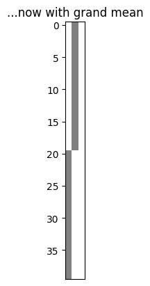

```python
aX = np.append(X, np.ones((np.sum(N),1)), axis=1) # Add grand mean to design matrix
plt.figure(); plt.imshow(aX, cmap='gray', vmin=-1, vmax=1);
plt.title('...now with grand mean'); plt.xticks([]);
B, sigma, R2, r   = glm_fit(y, aX)
T, F, df, p = glm_con(c, aX, B, sigma)
print(f'P-value from GLM with grand mean = {p.item():.3f}')
B = np.array2string(B.T[0])
print(f'Parameter (Beta) estimates = {B}')
print(f'Proportion of variance explained by model = {R2[0]:.3f}')
```

R2 - the proportion of variance explained - is a measure of overall model fit (and of effect size if hypothesis specified in terms of X).

Note however that the Bs have changed. This is because the first two now refer to deviations from the grand mean (rather than deviations from zero), ie B1 is what needs to be added to B3 to reproduce the mean of group 1, while B2 is what needs to be added to B3 to reproduce the mean of group 2.

Yet another possibility is to specify the model in terms of two colums of X: one for the difference between conditions and one for the average across condition (the constant term). This is essentially a rotation of original X by the transformation matrix "TM" below, so we can simply apply the same transformation to c to test the equivalent contrast:

```
P-value from GLM with grand mean = 0.067
Parameter (Beta) estimates = [0.2803492  0.27680089]
Proportion of variance explained by model = 0.108
```

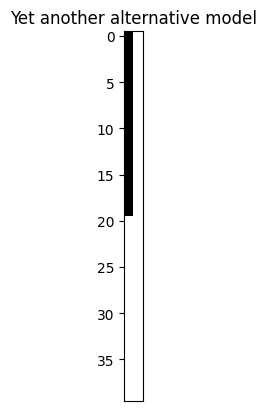

```python
TM = np.array([[-1, 1], [1, 1]]).T   # Transformation Matrix from separate groups to difference and mean across groups
aX = X@TM
plt.figure(); plt.imshow(aX, cmap='gray', vmin=-1, vmax=1)
plt.title('Yet another alternative model'); plt.xticks([]);
B, sigma, R2, r = glm_fit(y, aX)

ac = c@TM  # Since applied TM to X, need to apply to contrast too
T, F, df, p = glm_con(ac, aX, B, sigma)
B = np.array2string(B.T[0])
print(f'P-value from GLM with grand mean = {p.item():.3f}')
print(f'Parameter (Beta) estimates = {B}')
print(f'Proportion of variance explained by model = {R2[0]:.3f}')
```

Note that p-value and R2 are unchanged from above (because models span the same space). The Bs have again changed, because the first B now refers to how much one needs to add or subtract to the second B to reproduce the two group means respectively.

Note also that the scaling of c does not affect the statistics (though the sign does); nor does scaling of X (e.g, doubling the values in X will halve the values of B, but not affect the T-statistic, since both the numerator and denominator of the T-statistic are scaled by the same amount).

### GLM for paired T-test

We can now illustrate a paired T-test, where we simply add extra columns to X that capture the mean of each participant (note that the "glm_con" function pads any contrast vector c with 0's for any extra columns of X not included in the contrast vector provided):

```
Paired GLM: T(19)=4.24, p=0.000224
Unpaired GLM: T(38)=1.6, p=0.0593
```

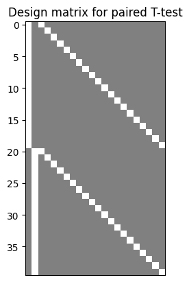

```python
N = 20
yg[0] = sample_pop(pop, N, 1);
yg[1] = yg[0] + np.random.randn(N,1)/2 + 0.5 # add signal with correlated effects across participants
y = np.concatenate(yg, axis=0)
X = np.append(np.kron(np.eye(2),np.ones((N,1))), np.kron(np.ones((2,1)),np.eye(N)), axis=1)
plt.figure(); plt.imshow(X, cmap='gray', vmin=-1, vmax=1);
plt.title('Design matrix for paired T-test'); plt.xticks([]);

T,F,df,p,B,R2,r = glm(y, X, c)
print(f'Paired GLM: T({int(df[1])})={T.item():.3}, p={p.item():.3}')

T,F,df,p,B,R2,r = glm(y, X[:,:2], c[:,:2])
print(f'Unpaired GLM: T({int(df[1])})={T.item():.3}, p={p.item():.3}')
```

Note again the smaller p-value for the paired than unpaired model, because its extra columns are capturing additional variance in the data, hence the residuals are smaller, and hence the T-value is higher, which often outweighs the loss in dfs (to the extent that there is between-participant variance in the data, as there is in above case since the data for condition 2 share a contribution from those in condition 1).

**Exercise: convince yourself that the above paired T-test can be reduced to a one-sample T-test within the GLM. Hint apply __TM = np.kron([-1, 1],np.eye(N))__ to X and c (noting that the GLM still works even though X is rank deficient, though you could also reduce __X@TM__ to just its second column, and adjust contrast __c__ to just [1]).**